# Red Wine Quality Analysis by Sun Xiaobing

This project was aimed to find Which chemical properties influence the quality of red wines. The data set was created by: Paulo Cortez (Univ. Minho), Antonio Cerdeira, Fernando Almeida, Telmo Matos and Jose Reis (CVRVV) @ 2009

We have downloaded the data set into our local directory, and first we load the data and have a look at it.

Take a look at the data.

```r
summary(wineQualityReds)
```

```
##  fixed.acidity   volatile.acidity  citric.acid    residual.sugar
##  Min.   : 4.60   Min.   :0.1200   Min.   :0.000   Min.   : 0.900
##  1st Qu.: 7.10   1st Qu.:0.3900   1st Qu.:0.090   1st Qu.: 1.900
##  Median : 7.90   Median :0.5200   Median :0.260   Median : 2.200
##  Mean   : 8.32   Mean   :0.5278   Mean   :0.271   Mean   : 2.539
##  3rd Qu.: 9.20   3rd Qu.:0.6400   3rd Qu.:0.420   3rd Qu.: 2.600
##  Max.   :15.90   Max.   :1.5800   Max.   :1.000   Max.   :15.500
##    chlorides       free.sulfur.dioxide total.sulfur.dioxide
##  Min.   :0.01200   Min.   : 1.00       Min.   :  6.00
##  1st Qu.:0.07000   1st Qu.: 7.00       1st Qu.: 22.00
##  Median :0.07900   Median :14.00       Median : 38.00
##  Mean   :0.08747   Mean   :15.87       Mean   : 46.47
##  3rd Qu.:0.09000   3rd Qu.:21.00       3rd Qu.: 62.00
##  Max.   :0.61100   Max.   :72.00       Max.   :289.00
##     density             pH          sulphates         alcohol
##  Min.   :0.9901   Min.   :2.740   Min.   :0.3300   Min.   : 8.40
##  1st Qu.:0.9956   1st Qu.:3.210   1st Qu.:0.5500   1st Qu.: 9.50
##  Median :0.9968   Median :3.310   Median :0.6200   Median :10.20
##  Mean   :0.9967   Mean   :3.311   Mean   :0.6581   Mean   :10.42
##  3rd Qu.:0.9978   3rd Qu.:3.400   3rd Qu.:0.7300   3rd Qu.:11.10
##  Max.   :1.0037   Max.   :4.010   Max.   :2.0000   Max.   :14.90
##     quality
##  Min.   :3.000
##  1st Qu.:5.000
##  Median :6.000
##  Mean   :5.636
##  3rd Qu.:6.000
##  Max.   :8.000
```

```r
head(wineQualityReds)
```

```
##   fixed.acidity volatile.acidity citric.acid residual.sugar chlorides
## 1           7.4             0.70        0.00            1.9     0.076
## 2           7.8             0.88        0.00            2.6     0.098
## 3           7.8             0.76        0.04            2.3     0.092
## 4          11.2             0.28        0.56            1.9     0.075
## 5           7.4             0.70        0.00            1.9     0.076
## 6           7.4             0.66        0.00            1.8     0.075
##   free.sulfur.dioxide total.sulfur.dioxide density   pH sulphates alcohol
## 1                  11                   34  0.9978 3.51      0.56     9.4
## 2                  25                   67  0.9968 3.20      0.68     9.8
## 3                  15                   54  0.9970 3.26      0.65     9.8
## 4                  17                   60  0.9980 3.16      0.58     9.8
## 5                  11                   34  0.9978 3.51      0.56     9.4
## 6                  13                   40  0.9978 3.51      0.56     9.4
##   quality
## 1       5
## 2       5
## 3       5
## 4       6
## 5       5
## 6       5
```

Let’s check missing values.

```r
apply(wineQualityReds,2,function(x){sum(is.na(x))})
```

```
##        fixed.acidity     volatile.acidity          citric.acid
##                    0                    0                    0
##       residual.sugar            chlorides  free.sulfur.dioxide
##                    0                    0                    0
## total.sulfur.dioxide              density                   pH
##                    0                    0                    0
##            sulphates              alcohol              quality
##                    0                    0                    0
```

No missing values here. # Univariate Plots Section We explore each feature by plotting histograms and doing statistics.

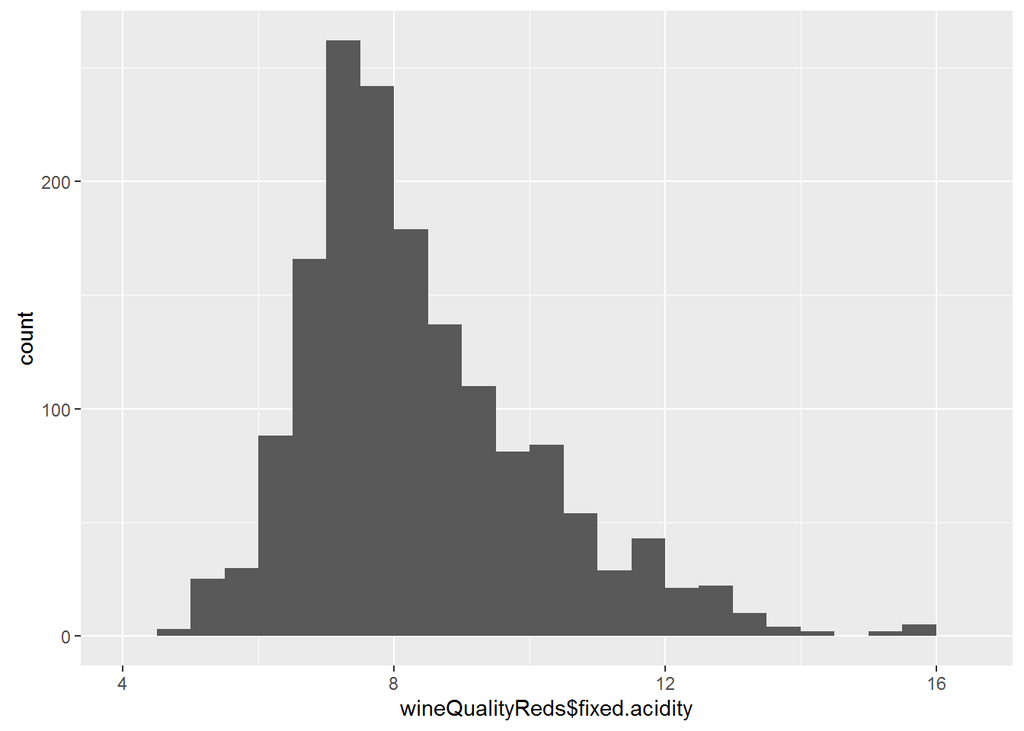

```r
qplot(wineQualityReds$fixed.acidity,binwidth=0.5)
```

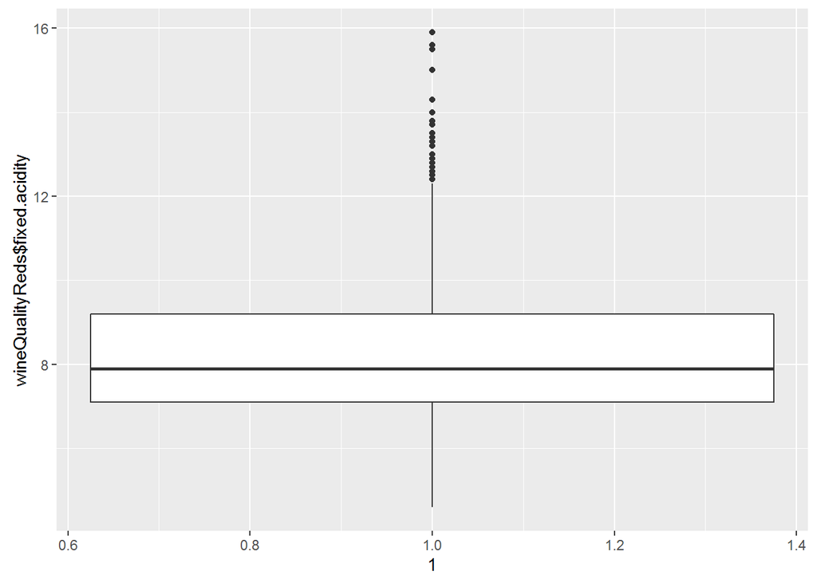

```r
qplot(1,wineQualityReds$fixed.acidity,geom="boxplot")
```

```r
out<-boxplot.stats(wineQualityReds$fixed.acidity)$out#Outliers
length(out)#number of outliers
```

```
## [1] 49
```

```r
summary(wineQualityReds$fixed.acidity)
```

```
##    Min. 1st Qu.  Median    Mean 3rd Qu.    Max.
##    4.60    7.10    7.90    8.32    9.20   15.90
```

```r
tapply(wineQualityReds$fixed.acidity,wineQualityReds$quality,mean)
```

```
##        3        4        5        6        7        8
## 8.360000 7.779245 8.167254 8.347179 8.872362 8.566667
```

Fixed acidity: most acids involved with wine or fixed or nonvolatile (do not evaporate readily). Most values concentrate between 6 and 11.There are 49 Outliers above 12.

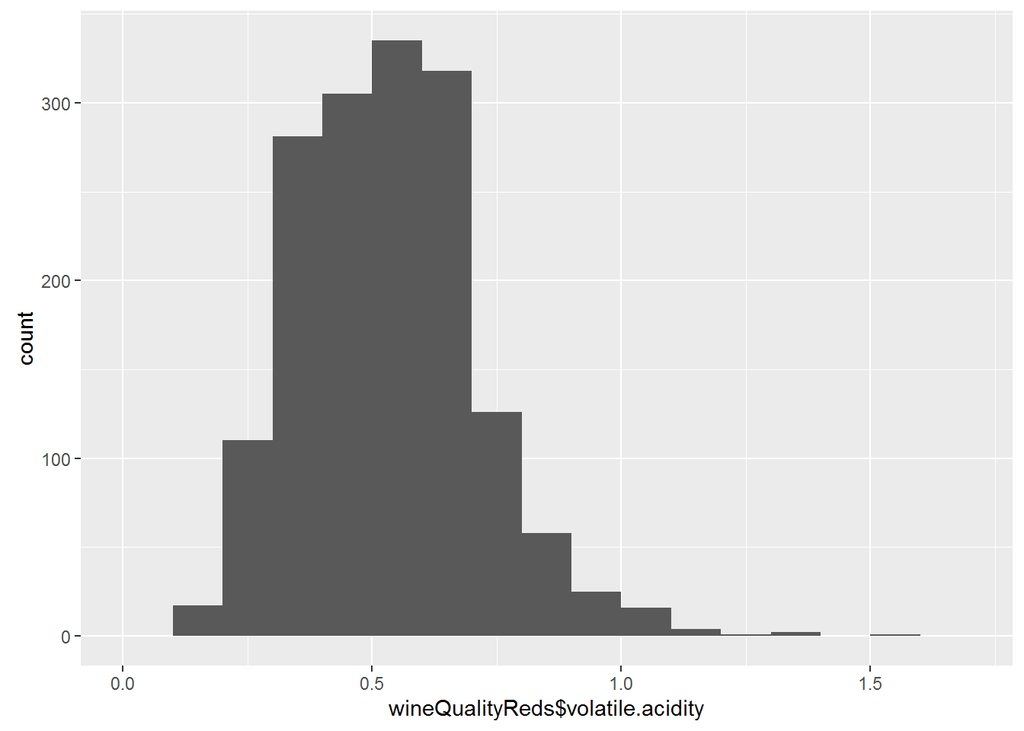

```r
qplot(wineQualityReds$volatile.acidity,binwidth=0.1)
```

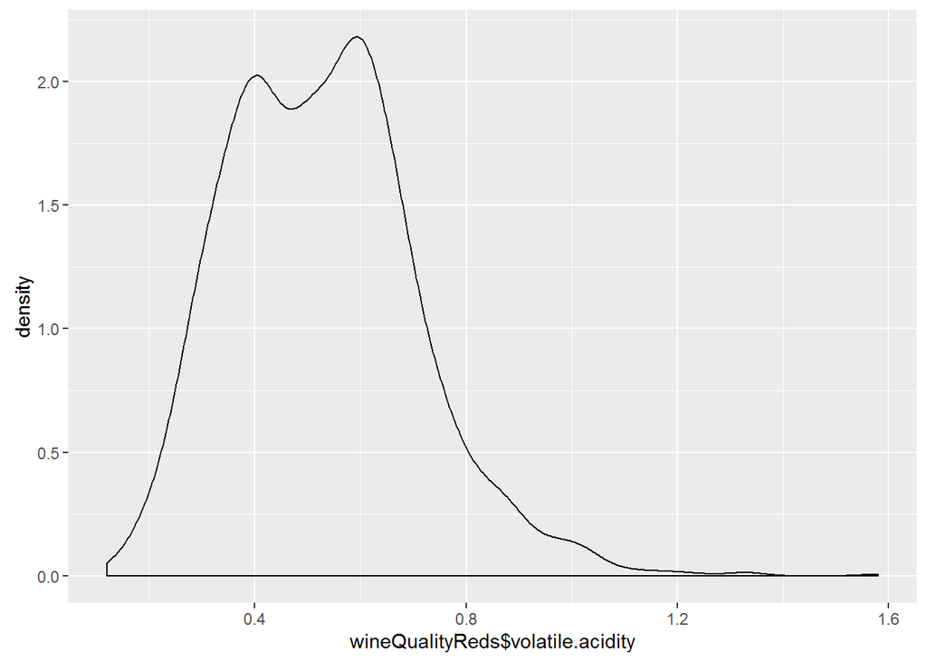

```r
qplot(wineQualityReds$volatile.acidity,geom="density")
```

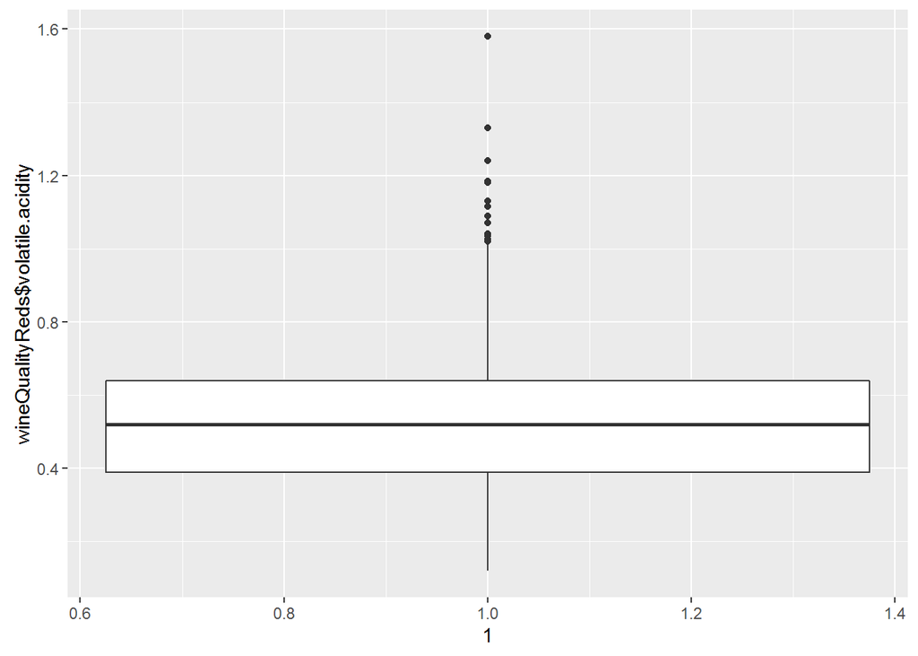

```r
qplot(1,wineQualityReds$volatile.acidity,geom="boxplot")
```

```r
out<-boxplot.stats(wineQualityReds$volatile.acidity)$out#Outliers
length(out)#number of outliers
```

```
## [1] 19
```

```r
summary(wineQualityReds$volatile.acidity)
```

```
##    Min. 1st Qu.  Median    Mean 3rd Qu.    Max.
##  0.1200  0.3900  0.5200  0.5278  0.6400  1.5800
```

```r
tapply(wineQualityReds$volatile.acidity,wineQualityReds$quality,mean)
```

```
##         3         4         5         6         7         8
## 0.8845000 0.6939623 0.5770411 0.4974843 0.4039196 0.4233333
```

Volatile acidity: the amount of acetic acid in wine, which at too high of levels can lead to an unpleasant, vinegar taste. It seems good red wines have less volatile acidity. Most values concentrate bewteen 0.25 and 0.8.

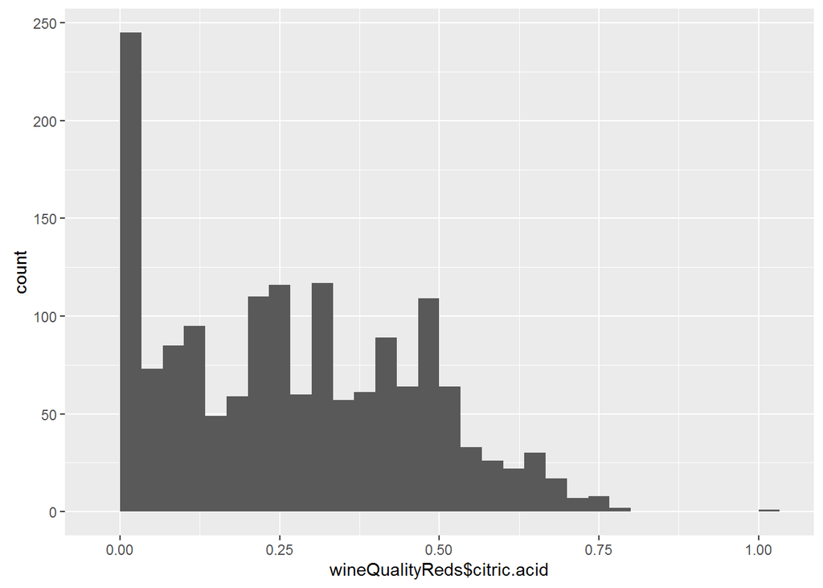

```r
qplot(wineQualityReds$citric.acid,bins=30)
```

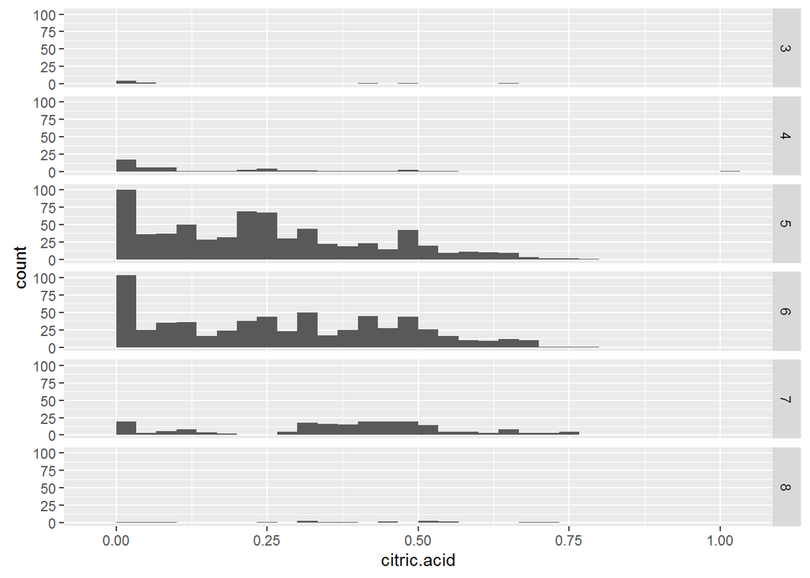

```r
qplot(citric.acid,data=wineQualityReds,geom="histogram",facets=quality~.,bins=30)
```

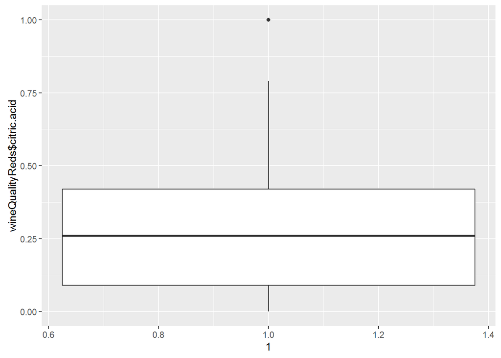

```r
qplot(1,wineQualityReds$citric.acid,geom="boxplot")
```

```r
out<-boxplot.stats(wineQualityReds$citric.acid)$out#Outliers
length(out)#number of outliers
```

```
## [1] 1
```

```r
summary(wineQualityReds$citric.acid)
```

```
##    Min. 1st Qu.  Median    Mean 3rd Qu.    Max.
##   0.000   0.090   0.260   0.271   0.420   1.000
```

```r
tapply(wineQualityReds$citric.acid,wineQualityReds$quality,mean)
```

```
##         3         4         5         6         7         8
## 0.1710000 0.1741509 0.2436858 0.2738245 0.3751759 0.3911111
```

```r
sum(wineQualityReds$citric.acid==0)
```

```
## [1] 132
```

Citric acid: found in small quantities, citric acid can add ‘freshness’ and flavor to wines. Good red wines have more citric acid averagely. Note: 132 citric.acid values are 0, perhaps the amounts are to small to detect. The data are quite skewed.

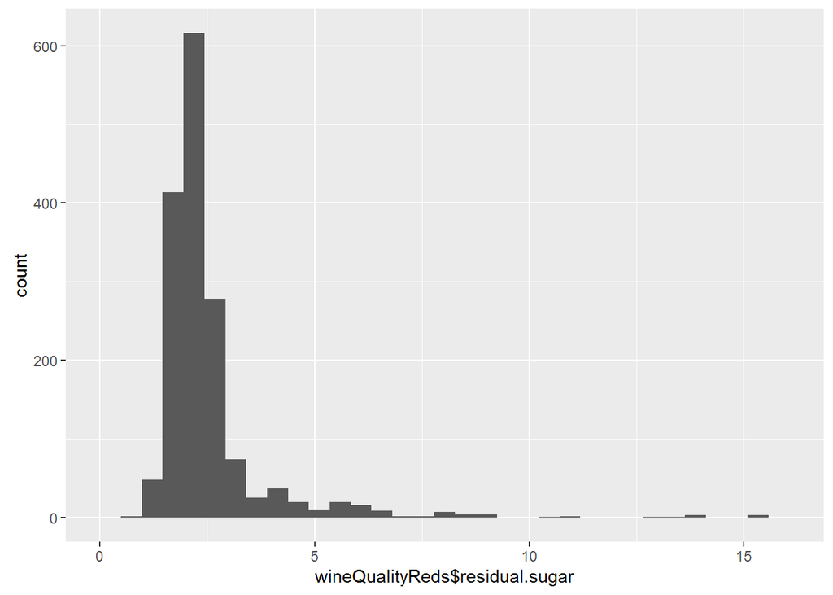

```r
qplot(wineQualityReds$residual.sugar,bins=30)
```

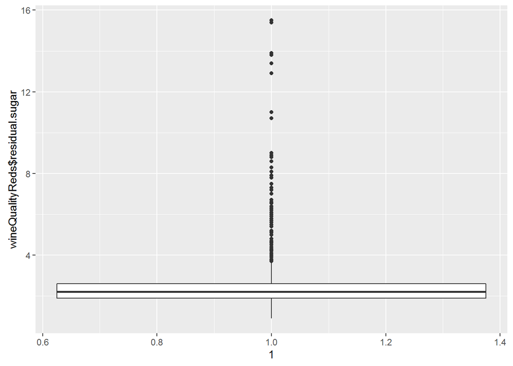

```r
qplot(1,wineQualityReds$residual.sugar,geom="boxplot")
```

```r
out<-boxplot.stats(wineQualityReds$residual.sugar)$out#Outliers
length(out)#number of outliers
```

```
## [1] 155
```

```r
summary(wineQualityReds$residual.sugar)
```

```
##    Min. 1st Qu.  Median    Mean 3rd Qu.    Max.
##   0.900   1.900   2.200   2.539   2.600  15.500
```

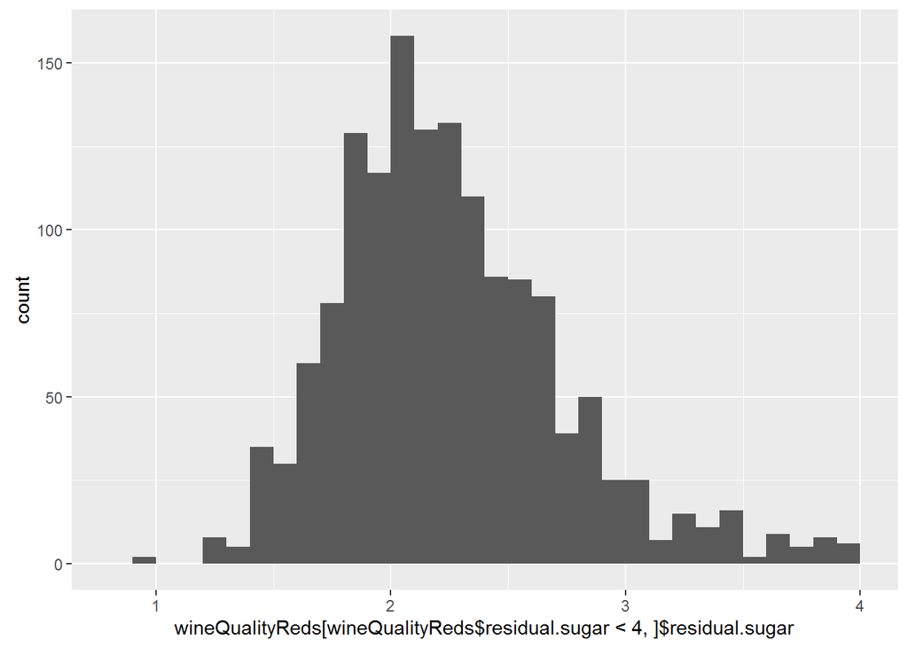

```r
qplot(wineQualityReds[wineQualityReds$residual.sugar<4,]$residual.sugar,bins=30)
```

```r
tapply(wineQualityReds$residual.sugar,wineQualityReds$quality,mean)
```

```
##        3        4        5        6        7        8
## 2.635000 2.694340 2.528855 2.477194 2.720603 2.577778
```

Residual sugar: the amount of sugar remaining after fermentation stops, it’s rare to find wines with less than 1 gram/liter and wines with greater than 45 grams/liter are considered sweet. Most values concentrate bewteen 1 and 3. There are 155 outliers. After removing the outliers, the distribution tend to be normal.

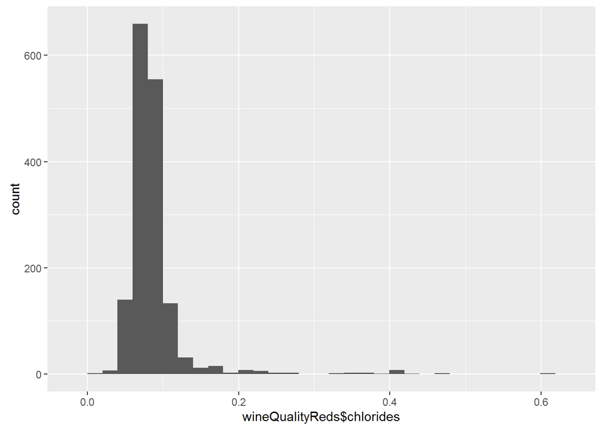

```r
qplot(wineQualityReds$chlorides,bins=30)
```

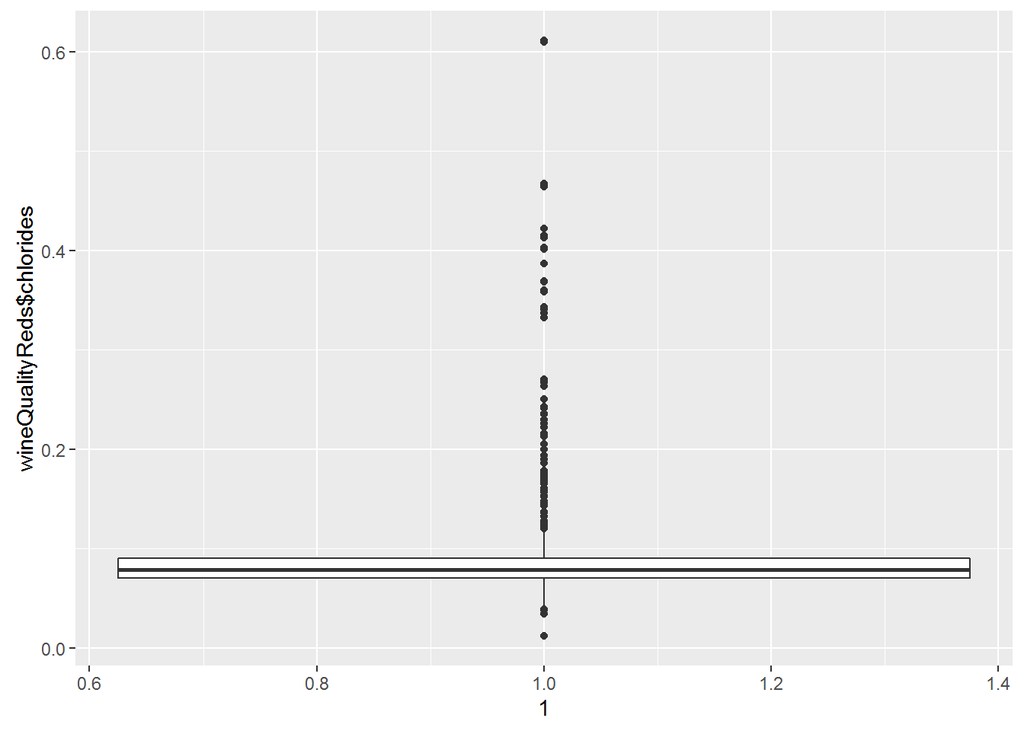

```r
qplot(1,wineQualityReds$chlorides,geom="boxplot")
```

```r
out<-boxplot.stats(wineQualityReds$chlorides)$out#Outliers
length(out)#number of outliers
```

```
## [1] 112
```

```r
summary(wineQualityReds$chlorides)
```

```
##    Min. 1st Qu.  Median    Mean 3rd Qu.    Max.
## 0.01200 0.07000 0.07900 0.08747 0.09000 0.61100
```

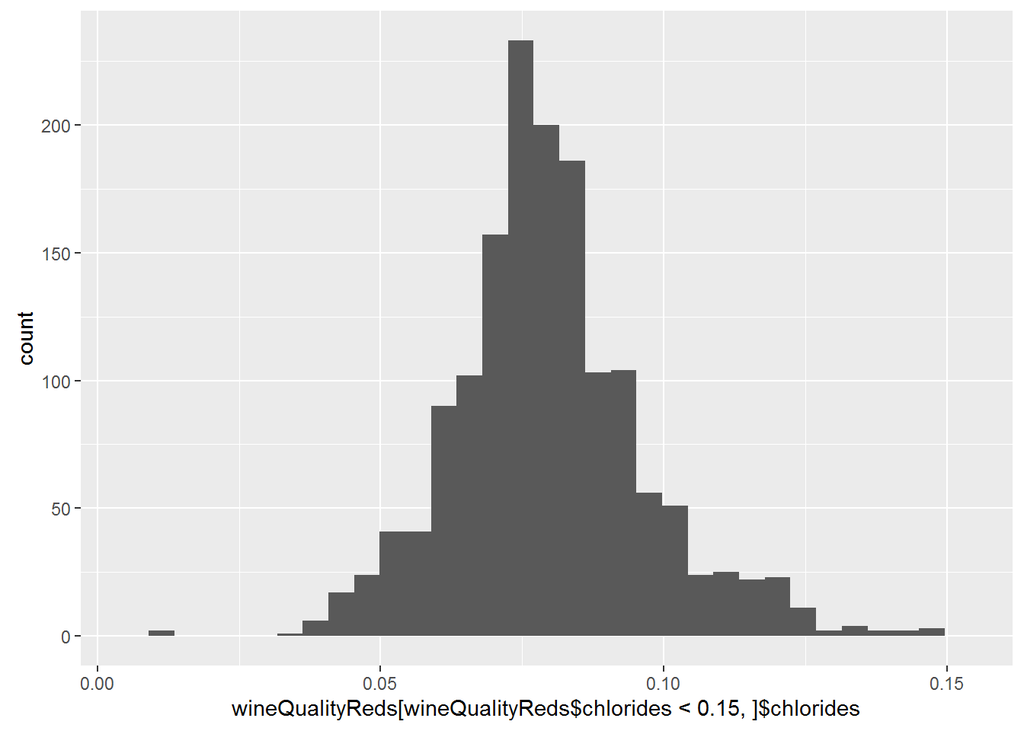

```r
qplot(wineQualityReds[wineQualityReds$chlorides<0.15,]$chlorides,bins=30)
```

```r
tapply(wineQualityReds$chlorides,wineQualityReds$quality,mean)
```

```
##          3          4          5          6          7          8
## 0.12250000 0.09067925 0.09273568 0.08495611 0.07658794 0.06844444
```

Chlorides: the amount of salt in the wine. Good wines tend to have less amount. Most values concentrate between 0.07 and 0.1. Also there are 112 outliers. After removing the outliers, the distribution tend to be normal.

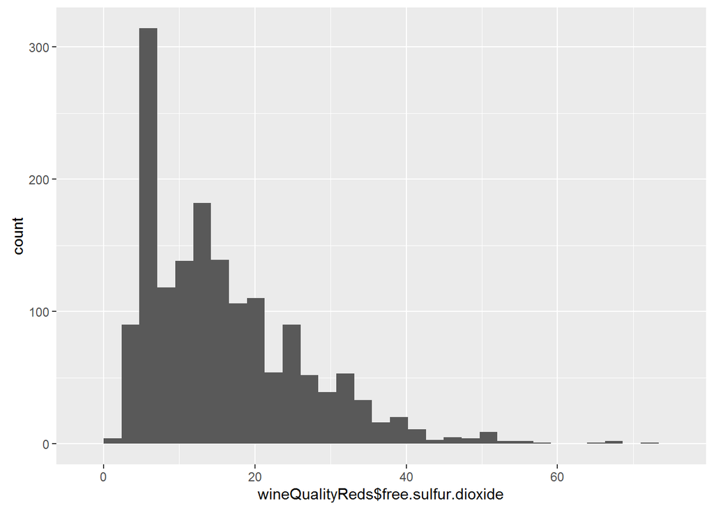

```r
qplot(wineQualityReds$free.sulfur.dioxide,bins=30)
```

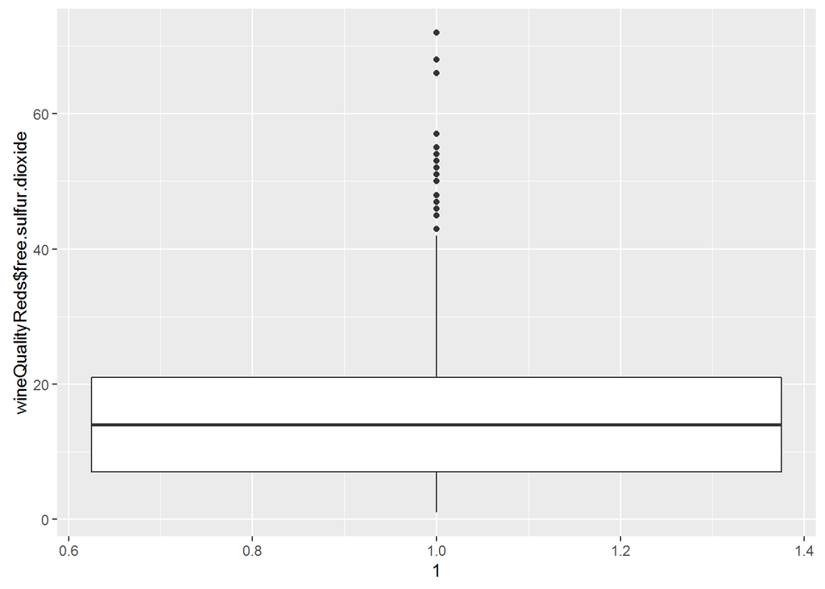

```r
qplot(1,wineQualityReds$free.sulfur.dioxide,geom="boxplot")
```

```r
out<-boxplot.stats(wineQualityReds$free.sulfur.dioxide)$out#Outliers
length(out)#number of outliers
```

```
## [1] 30
```

```r
summary(wineQualityReds$free.sulfur.dioxide)
```

```
##    Min. 1st Qu.  Median    Mean 3rd Qu.    Max.
##    1.00    7.00   14.00   15.87   21.00   72.00
```

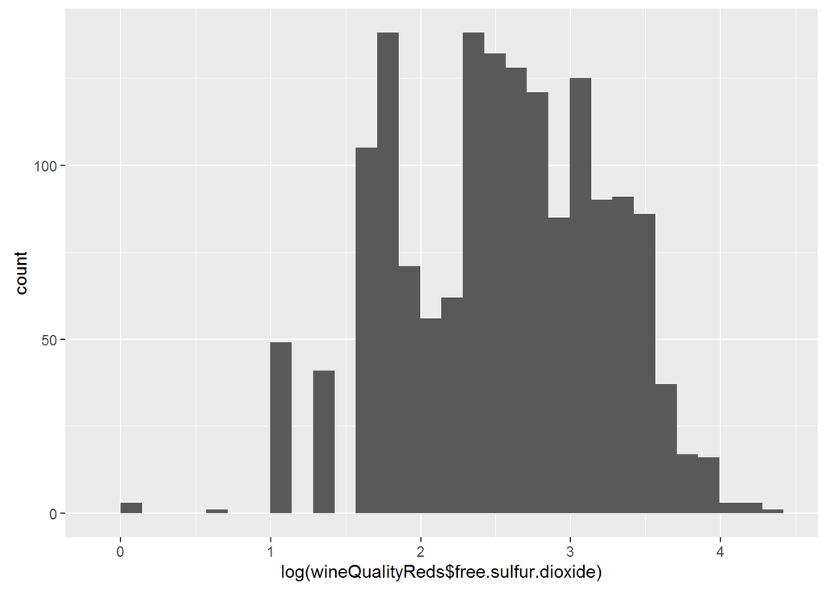

```r
qplot(log(wineQualityReds$free.sulfur.dioxide),bins=30)
```

```r
tapply(wineQualityReds$free.sulfur.dioxide,wineQualityReds$quality,mean)
```

```
##        3        4        5        6        7        8
## 11.00000 12.26415 16.98385 15.71160 14.04523 13.27778
```

Free sulfur dioxide: the free form of SO2 exists in equilibrium between molecular SO2 (as a dissolved gas) and bisulfite ion; it prevents microbial growth and the oxidation of wine. Most values concentrate between 7 and 23. The data is skewed.

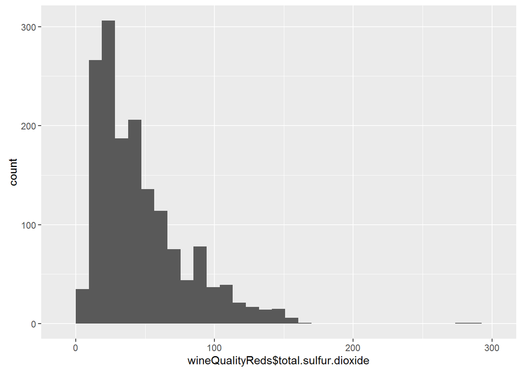

```r
qplot(wineQualityReds$total.sulfur.dioxide,bins=30)
```

```r
summary(wineQualityReds$total.sulfur.dioxide)
```

```
##    Min. 1st Qu.  Median    Mean 3rd Qu.    Max.
##    6.00   22.00   38.00   46.47   62.00  289.00
```

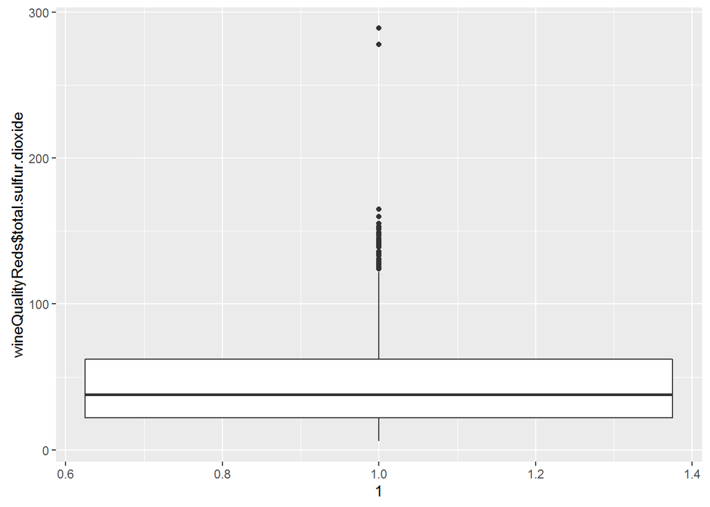

```r
qplot(1,wineQualityReds$total.sulfur.dioxide,geom="boxplot")
```

```r
out<-boxplot.stats(wineQualityReds$total.sulfur.dioxide)$out#Outliers
length(out)#number of outliers
```

```
## [1] 55
```

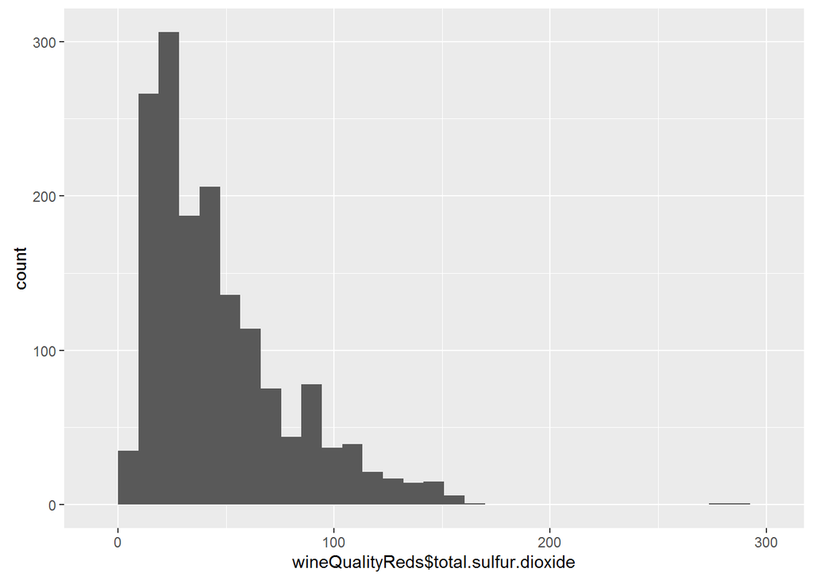

```r
qplot(wineQualityReds$total.sulfur.dioxide,bins=30)
```

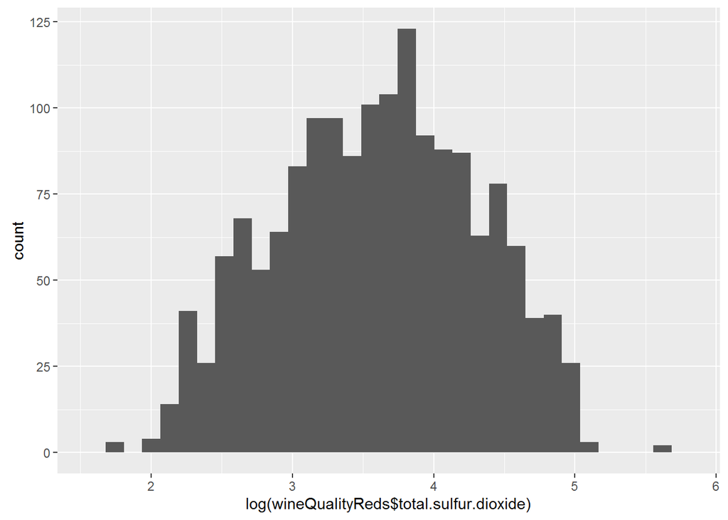

```r
qplot(log(wineQualityReds$total.sulfur.dioxide),bins=30)
```

```r
tapply(wineQualityReds$total.sulfur.dioxide,wineQualityReds$quality,mean)
```

```
##        3        4        5        6        7        8
## 24.90000 36.24528 56.51395 40.86991 35.02010 33.44444
```

Total sulfur dioxide: amount of free and bound forms of S02; in low concentrations, SO2 is mostly undetectable in wine, but at free SO2 concentrations over 50 ppm, SO2 becomes evident in the nose and taste of wine. The values are quite skewed, so we need transform them into log values. Most values concentrate between 22 and 100. In ordert to analyze bound form sulfur sulfur dioxide, we create a new variable bf.sulfur.dioxide.

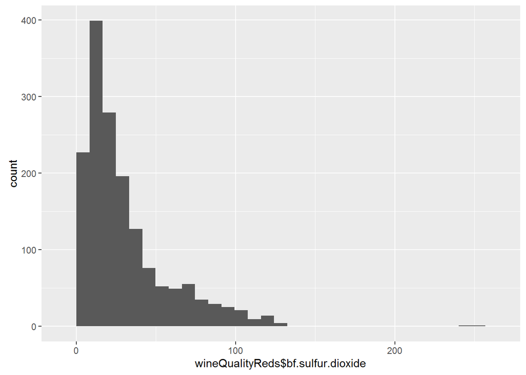

```r
wineQualityReds<-mutate(wineQualityReds, bf.sulfur.dioxide=total.sulfur.dioxide-free.sulfur.dioxide)
qplot(wineQualityReds$bf.sulfur.dioxide,bins=30)
```

```r
summary(wineQualityReds$bf.sulfur.dioxide)
```

```
##    Min. 1st Qu.  Median    Mean 3rd Qu.    Max.
##    3.00   12.00   21.00   30.59   39.00  251.50
```

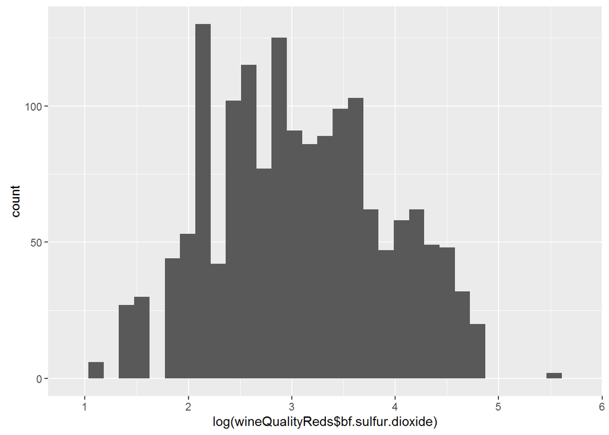

```r
qplot(log(wineQualityReds$bf.sulfur.dioxide),bins=30)
```

```r
tapply(wineQualityReds$bf.sulfur.dioxide,wineQualityReds$quality,mean)
```

```
##        3        4        5        6        7        8
## 13.90000 23.98113 39.53010 25.15831 20.97487 20.16667
```

The values are quite skewed. We can transform them.

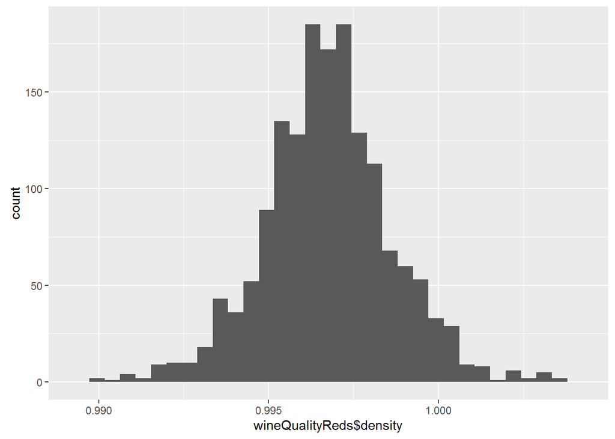

```r
qplot(wineQualityReds$density,bins=30)
```

```r
summary(wineQualityReds$density)
```

```
##    Min. 1st Qu.  Median    Mean 3rd Qu.    Max.
##  0.9901  0.9956  0.9968  0.9967  0.9978  1.0040
```

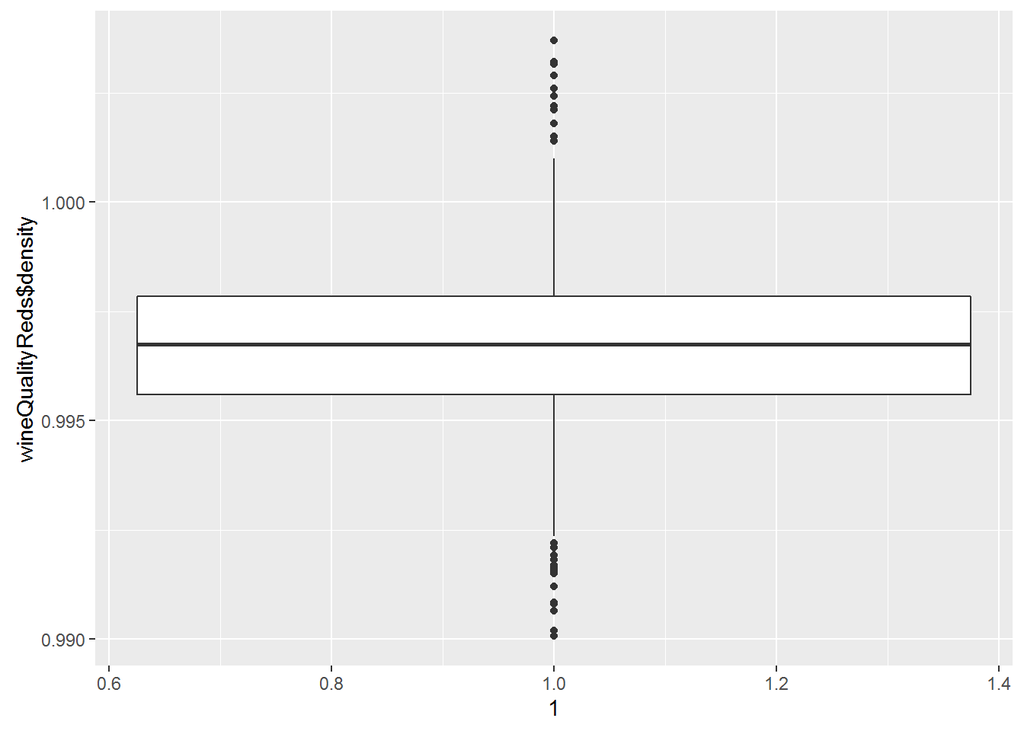

```r
qplot(1,wineQualityReds$density,geom="boxplot")
```

```r
out<-boxplot.stats(wineQualityReds$density)$out#Outliers
length(out)#number of outliers
```

```
## [1] 45
```

```r
tapply(wineQualityReds$density,wineQualityReds$quality,mean)
```

```
##         3         4         5         6         7         8
## 0.9974640 0.9965425 0.9971036 0.9966151 0.9961043 0.9952122
```

Density: the density of water is close to that of water depending on the percent alcohol and sugar content. The density does not change much. Most values are between 0.99 and 1

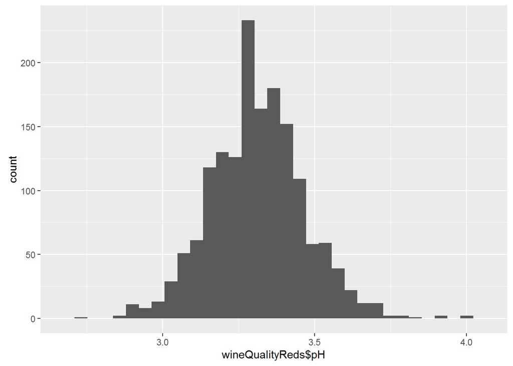

```r
qplot(wineQualityReds$pH,bins=30)
```

```r
summary(wineQualityReds$pH)
```

```
##    Min. 1st Qu.  Median    Mean 3rd Qu.    Max.
##   2.740   3.210   3.310   3.311   3.400   4.010
```

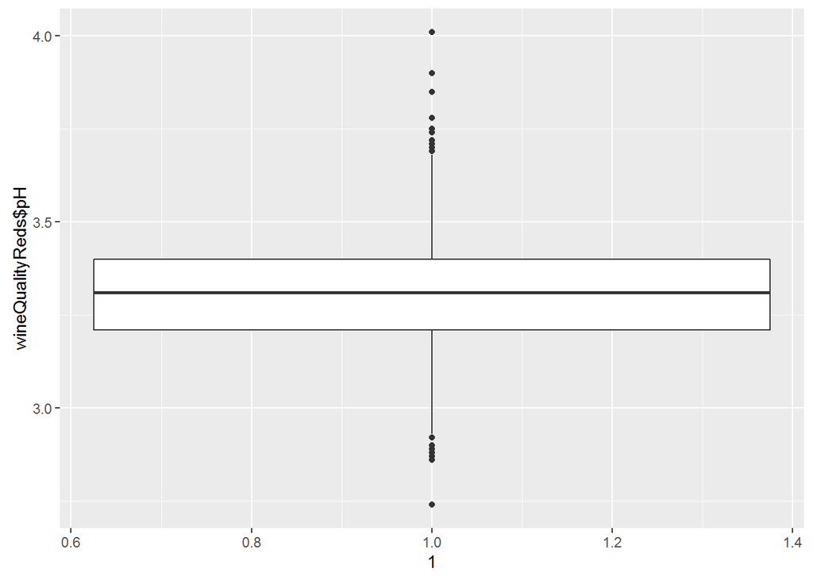

```r
qplot(1,wineQualityReds$pH,geom="boxplot")
```

```r
out<-boxplot.stats(wineQualityReds$pH)$out#Outliers
length(out)#number of outliers
```

```
## [1] 35
```

```r
tapply(wineQualityReds$pH,wineQualityReds$quality,mean)
```

```
##        3        4        5        6        7        8
## 3.398000 3.381509 3.304949 3.318072 3.290754 3.267222
```

PH: describes how acidic or basic a wine is on a scale from 0 (very acidic) to 14 (very basic); most wines are between 3-4 on the pH scale. It seems good red wines tend to be less in pH. Most values are between 3 and 3.6. Some outliers exist.

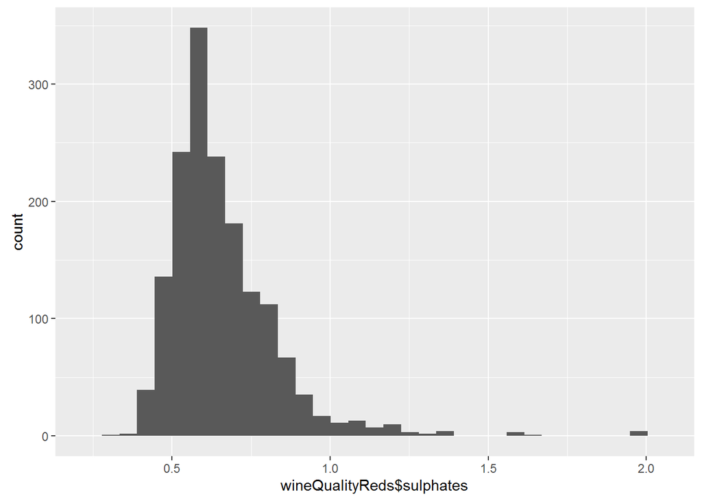

```r
qplot(wineQualityReds$sulphates,bins=30)
```

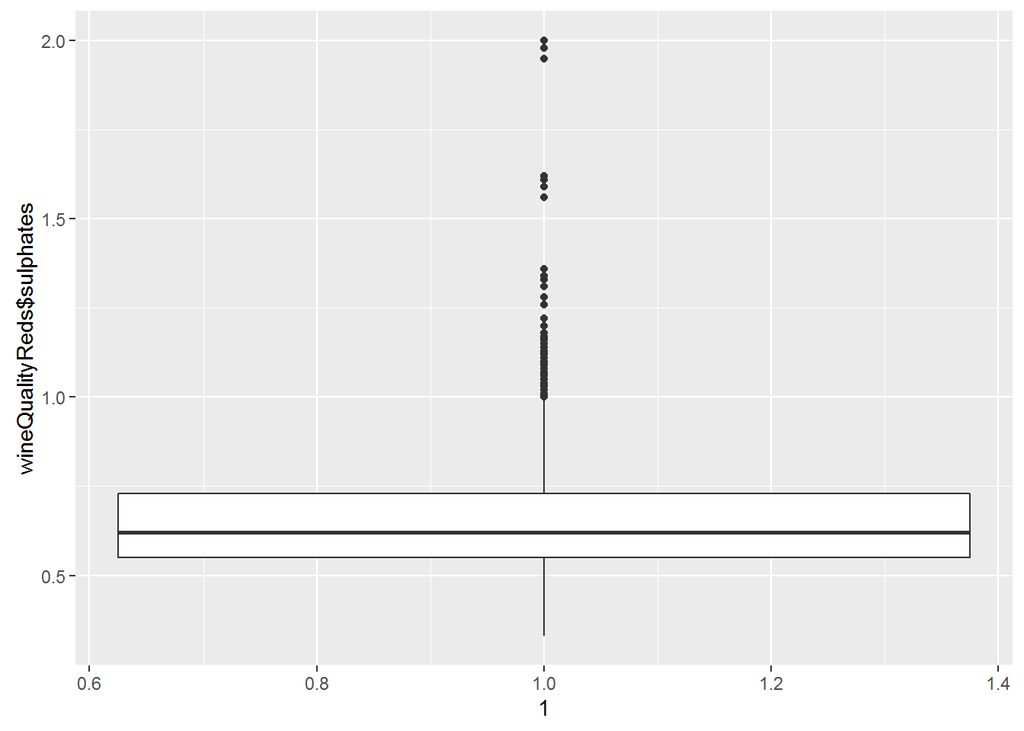

```r
qplot(1,wineQualityReds$sulphates,geom="boxplot")
```

```r
out<-boxplot.stats(wineQualityReds$sulphates)$out#Outliers
length(out)#number of outliers
```

```
## [1] 59
```

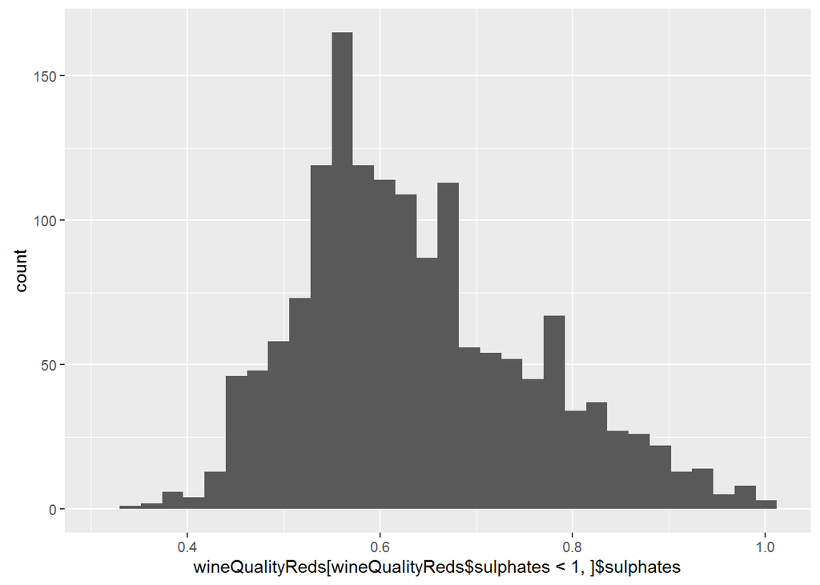

```r
qplot(wineQualityReds[wineQualityReds$sulphates<1,]$sulphates,bins=30)
```

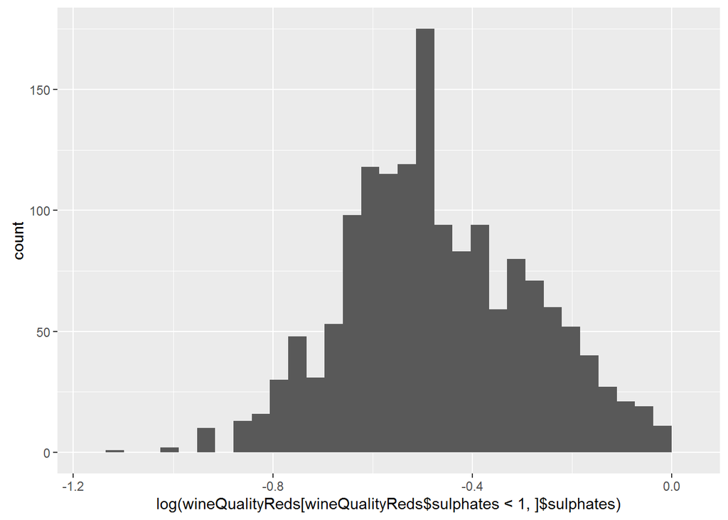

```r
qplot(log(wineQualityReds[wineQualityReds$sulphates<1,]$sulphates),bins=30)
```

```r
summary(wineQualityReds$sulphates)
```

```
##    Min. 1st Qu.  Median    Mean 3rd Qu.    Max.
##  0.3300  0.5500  0.6200  0.6581  0.7300  2.0000
```

```r
tapply(wineQualityReds$sulphates,wineQualityReds$quality,mean)
```

```
##         3         4         5         6         7         8
## 0.5700000 0.5964151 0.6209692 0.6753292 0.7412563 0.7677778
```

sulphates: a wine additive which can contribute to sulfur dioxide gas (S02) levels, wich acts as an antimicrobial and antioxidant. Most values are between 0.4 and 0.8. Good wines tend to contain more sulphates. The values are a little skewed. There are 59 outliers. After removing the outliers, it is less skewed.

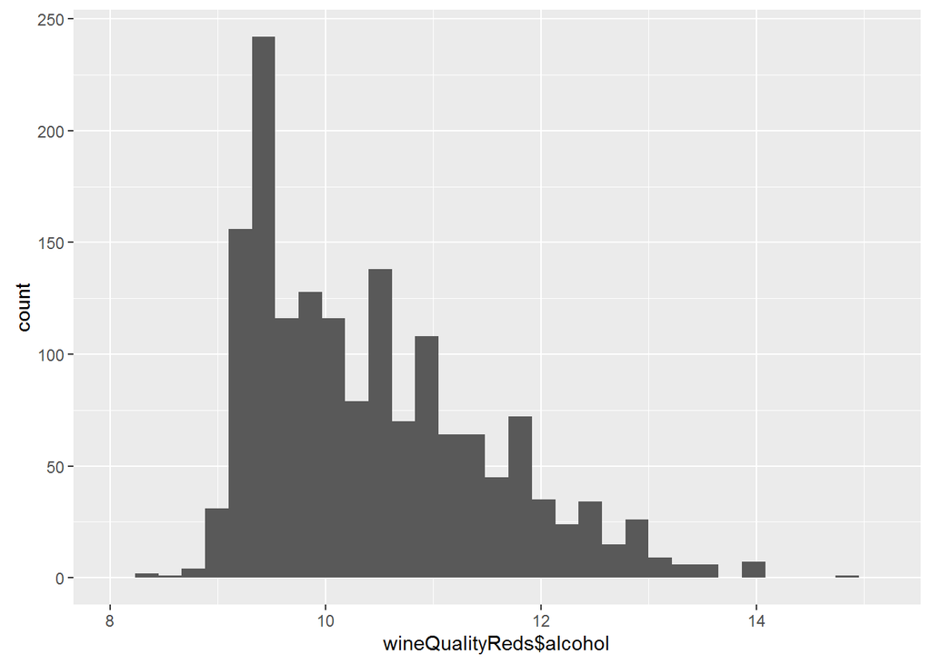

```r
qplot(wineQualityReds$alcohol,bins=30)
```

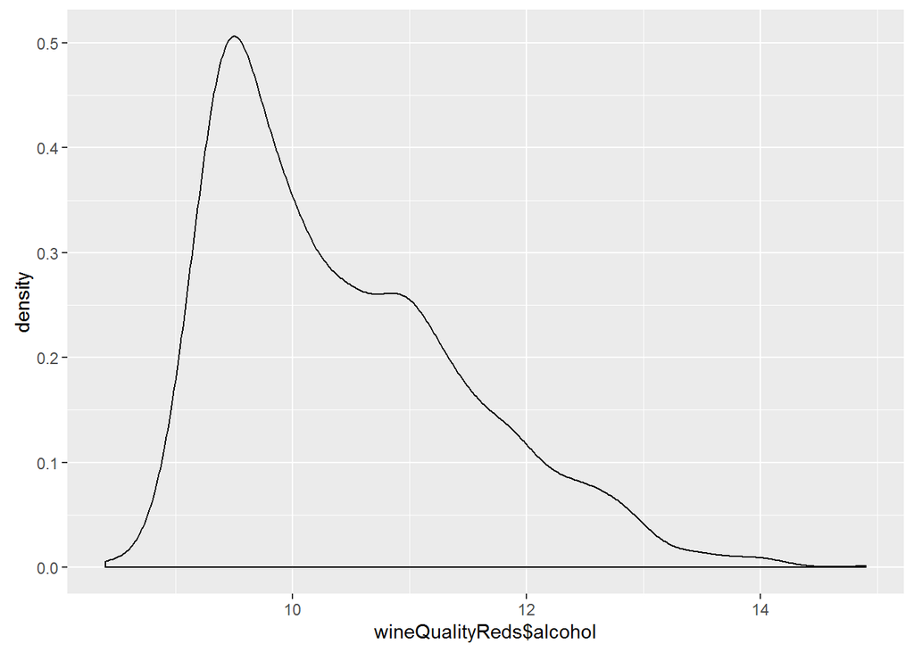

```r
qplot(wineQualityReds$alcohol,geom="density")
```

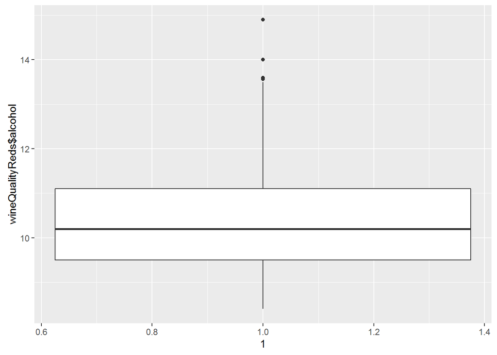

```r
qplot(1,wineQualityReds$alcohol,geom="boxplot")
```

```r
out<-boxplot.stats(wineQualityReds$alcohol)$out#Outliers
length(out)#number of outliers
```

```
## [1] 13
```

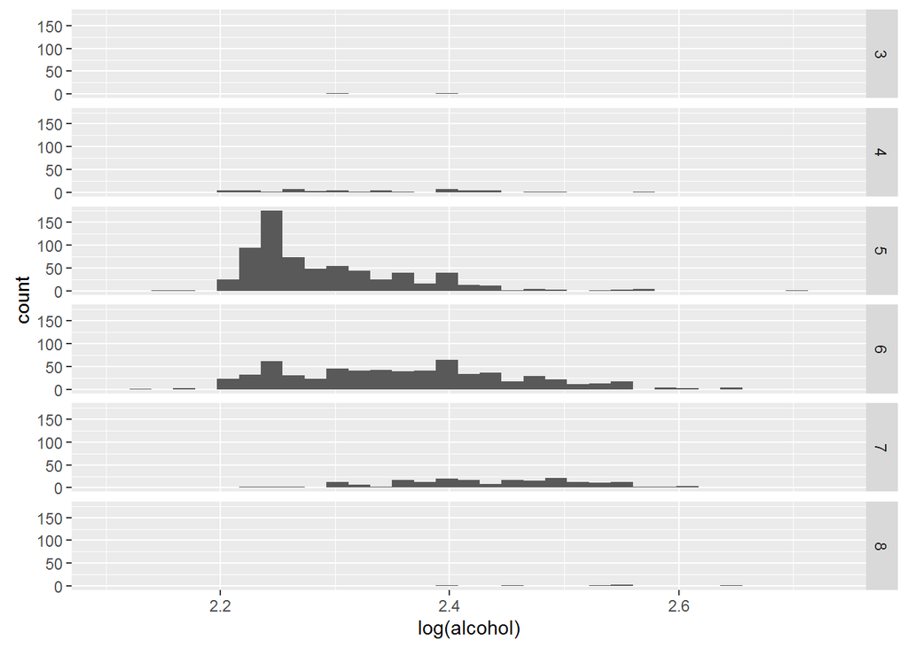

```r
qplot(log(alcohol),data=wineQualityReds,facets=quality~.,bins=30)
```

```r
summary(wineQualityReds$alcohol)
```

```
##    Min. 1st Qu.  Median    Mean 3rd Qu.    Max.
##    8.40    9.50   10.20   10.42   11.10   14.90
```

```r
tapply(wineQualityReds$alcohol,wineQualityReds$quality,mean)
```

```
##         3         4         5         6         7         8
##  9.955000 10.265094  9.899706 10.629519 11.465913 12.094444
```

Alcohol: the percent alcohol content of the wine. Most values are between 9 and 12. The values are skewed, enven after log transformation. Exactly, red wines of Qulaity 5 and 6 have very strong impact on the distribution because of their numbers.

# Univariate Analysis

### What is the structure of your dataset?

```r
dim(wineQualityReds)
```

```
## [1] 1599   13
```

```r
str(wineQualityReds)
```

```
## 'data.frame':    1599 obs. of  13 variables:
##  $ fixed.acidity       : num  7.4 7.8 7.8 11.2 7.4 7.4 7.9 7.3 7.8 7.5 ...
##  $ volatile.acidity    : num  0.7 0.88 0.76 0.28 0.7 0.66 0.6 0.65 0.58 0.5 ...
##  $ citric.acid         : num  0 0 0.04 0.56 0 0 0.06 0 0.02 0.36 ...
##  $ residual.sugar      : num  1.9 2.6 2.3 1.9 1.9 1.8 1.6 1.2 2 6.1 ...
##  $ chlorides           : num  0.076 0.098 0.092 0.075 0.076 0.075 0.069 0.065 0.073 0.071 ...
##  $ free.sulfur.dioxide : num  11 25 15 17 11 13 15 15 9 17 ...
##  $ total.sulfur.dioxide: num  34 67 54 60 34 40 59 21 18 102 ...
##  $ density             : num  0.998 0.997 0.997 0.998 0.998 ...
##  $ pH                  : num  3.51 3.2 3.26 3.16 3.51 3.51 3.3 3.39 3.36 3.35 ...
##  $ sulphates           : num  0.56 0.68 0.65 0.58 0.56 0.56 0.46 0.47 0.57 0.8 ...
##  $ alcohol             : num  9.4 9.8 9.8 9.8 9.4 9.4 9.4 10 9.5 10.5 ...
##  $ quality             : int  5 5 5 6 5 5 5 7 7 5 ...
##  $ bf.sulfur.dioxide   : num  23 42 39 43 23 27 44 6 9 85 ...
```

```r
names(wineQualityReds)
```

```
##  [1] "fixed.acidity"        "volatile.acidity"     "citric.acid"
##  [4] "residual.sugar"       "chlorides"            "free.sulfur.dioxide"
##  [7] "total.sulfur.dioxide" "density"              "pH"
## [10] "sulphates"            "alcohol"              "quality"
## [13] "bf.sulfur.dioxide"
```

```r
table(wineQualityReds$quality)
```

```
##
##   3   4   5   6   7   8
##  10  53 681 638 199  18
```

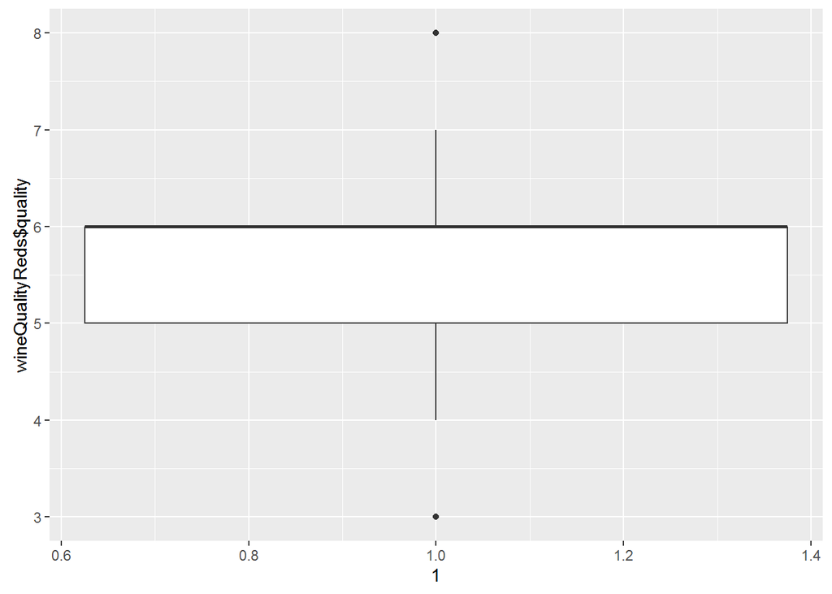

```r
qplot(1,wineQualityReds$quality,geom="boxplot")
```

```r
wineQualityReds2<-mutate(wineQualityReds,log.total.sulfur.dioxide=log(total.sulfur.dioxide),log.bf.sulfur.dioxide=log(bf.sulfur.dioxide),log.free.sulfur.dioxide=log(free.sulfur.dioxide),log.alcohol=log(alcohol))
wineQualityReds2<-select(wineQualityReds2,-total.sulfur.dioxide,-bf.sulfur.dioxide,-free.sulfur.dioxide,-alcohol)
```

# Bivariate Plots Section

```r
cor(wineQualityReds2)###pairs(wineQualityReds2)
```

```
##                          fixed.acidity volatile.acidity  citric.acid
## fixed.acidity               1.00000000     -0.256130895  0.671703435
## volatile.acidity           -0.25613089      1.000000000 -0.552495685
## citric.acid                 0.67170343     -0.552495685  1.000000000
## residual.sugar              0.11477672      0.001917882  0.143577162
## chlorides                   0.09370519      0.061297772  0.203822914
## density                     0.66804729      0.022026232  0.364947175
## pH                         -0.68297819      0.234937294 -0.541904145
## sulphates                   0.18300566     -0.260986685  0.312770044
## quality                     0.12405165     -0.390557780  0.226372514
## log.total.sulfur.dioxide   -0.11789982      0.073407103 -0.003637462
## log.bf.sulfur.dioxide      -0.04820219      0.079882210  0.061634875
## log.free.sulfur.dioxide    -0.17921083      0.016666386 -0.089146031
## log.alcohol                -0.05795932     -0.201443659  0.108960977
##                          residual.sugar   chlorides     density
## fixed.acidity               0.114776724  0.09370519  0.66804729
## volatile.acidity            0.001917882  0.06129777  0.02202623
## citric.acid                 0.143577162  0.20382291  0.36494718
## residual.sugar              1.000000000  0.05560954  0.35528337
## chlorides                   0.055609535  1.00000000  0.20063233
## density                     0.355283371  0.20063233  1.00000000
## pH                         -0.085652422 -0.26502613 -0.34169933
## sulphates                   0.005527121  0.37126048  0.14850641
## quality                     0.013731637 -0.12890656 -0.17491923
## log.total.sulfur.dioxide    0.147471411  0.06022193  0.10553948
## log.bf.sulfur.dioxide       0.151606573  0.08794616  0.18554926
## log.free.sulfur.dioxide     0.107006201 -0.00389842 -0.03964203
## log.alcohol                 0.039034406 -0.22579132 -0.49094833
##                                   pH    sulphates     quality
## fixed.acidity            -0.68297819  0.183005664  0.12405165
## volatile.acidity          0.23493729 -0.260986685 -0.39055778
## citric.acid              -0.54190414  0.312770044  0.22637251
## residual.sugar           -0.08565242  0.005527121  0.01373164
## chlorides                -0.26502613  0.371260481 -0.12890656
## density                  -0.34169933  0.148506412 -0.17491923
## pH                        1.00000000 -0.196647602 -0.05773139
## sulphates                -0.19664760  1.000000000  0.25139708
## quality                  -0.05773139  0.251397079  1.00000000
## log.total.sulfur.dioxide -0.01483664  0.069754799 -0.17014272
## log.bf.sulfur.dioxide    -0.07835501  0.061350560 -0.20830074
```

[output cut: 15 more lines]

```
## log.alcohol                          -0.238093442           -0.28889692
##                          log.free.sulfur.dioxide log.alcohol
## fixed.acidity                        -0.17921083 -0.05795932
## volatile.acidity                      0.01666639 -0.20144366
## citric.acid                          -0.08914603  0.10896098
## residual.sugar                        0.10700620  0.03903441
## chlorides                            -0.00389842 -0.22579132
## density                              -0.03964203 -0.49094833
## pH                                    0.09576315  0.20620939
## sulphates                             0.05519815  0.09366872
## quality                              -0.05008749  0.47698109
## log.total.sulfur.dioxide              0.78462175 -0.23809344
## log.bf.sulfur.dioxide                 0.55382084 -0.28889692
## log.free.sulfur.dioxide               1.00000000 -0.08422103
## log.alcohol                          -0.08422103  1.00000000
```

```r
apply(abs(cor(wineQualityReds2))>0.5,2,sum)
```

```
##            fixed.acidity         volatile.acidity              citric.acid
##                        4                        2                        4
##           residual.sugar                chlorides                  density
##                        1                        1                        2
##                       pH                sulphates                  quality
##                        3                        1                        1
## log.total.sulfur.dioxide    log.bf.sulfur.dioxide  log.free.sulfur.dioxide
##                        3                        3                        3
##              log.alcohol
##                        1
```

```r
abs(cor(wineQualityReds2))>0.6
```

```
##                          fixed.acidity volatile.acidity citric.acid
## fixed.acidity                     TRUE            FALSE        TRUE
## volatile.acidity                 FALSE             TRUE       FALSE
## citric.acid                       TRUE            FALSE        TRUE
## residual.sugar                   FALSE            FALSE       FALSE
## chlorides                        FALSE            FALSE       FALSE
## density                           TRUE            FALSE       FALSE
## pH                                TRUE            FALSE       FALSE
## sulphates                        FALSE            FALSE       FALSE
## quality                          FALSE            FALSE       FALSE
## log.total.sulfur.dioxide         FALSE            FALSE       FALSE
## log.bf.sulfur.dioxide            FALSE            FALSE       FALSE
## log.free.sulfur.dioxide          FALSE            FALSE       FALSE
## log.alcohol                      FALSE            FALSE       FALSE
##                          residual.sugar chlorides density    pH sulphates
## fixed.acidity                     FALSE     FALSE    TRUE  TRUE     FALSE
## volatile.acidity                  FALSE     FALSE   FALSE FALSE     FALSE
## citric.acid                       FALSE     FALSE   FALSE FALSE     FALSE
## residual.sugar                     TRUE     FALSE   FALSE FALSE     FALSE
## chlorides                         FALSE      TRUE   FALSE FALSE     FALSE
## density                           FALSE     FALSE    TRUE FALSE     FALSE
## pH                                FALSE     FALSE   FALSE  TRUE     FALSE
## sulphates                         FALSE     FALSE   FALSE FALSE      TRUE
## quality                           FALSE     FALSE   FALSE FALSE     FALSE
## log.total.sulfur.dioxide          FALSE     FALSE   FALSE FALSE     FALSE
## log.bf.sulfur.dioxide             FALSE     FALSE   FALSE FALSE     FALSE
## log.free.sulfur.dioxide           FALSE     FALSE   FALSE FALSE     FALSE
## log.alcohol                       FALSE     FALSE   FALSE FALSE     FALSE
##                          quality log.total.sulfur.dioxide
## fixed.acidity              FALSE                    FALSE
## volatile.acidity           FALSE                    FALSE
## citric.acid                FALSE                    FALSE
## residual.sugar             FALSE                    FALSE
## chlorides                  FALSE                    FALSE
## density                    FALSE                    FALSE
## pH                         FALSE                    FALSE
## sulphates                  FALSE                    FALSE
## quality                     TRUE                    FALSE
## log.total.sulfur.dioxide   FALSE                     TRUE
## log.bf.sulfur.dioxide      FALSE                     TRUE
```

[output cut: 15 more lines]

```
## log.alcohol                              FALSE                   FALSE
##                          log.alcohol
## fixed.acidity                  FALSE
## volatile.acidity               FALSE
## citric.acid                    FALSE
## residual.sugar                 FALSE
## chlorides                      FALSE
## density                        FALSE
## pH                             FALSE
## sulphates                      FALSE
## quality                        FALSE
## log.total.sulfur.dioxide       FALSE
## log.bf.sulfur.dioxide          FALSE
## log.free.sulfur.dioxide        FALSE
## log.alcohol                     TRUE
```

The table shows some features are correlated, i.e., (citric.acid, fixed.acidity), (density,fixed.acidity), (pH, fixed.acidity), (citric.acid) and etc. Note: fixed.acidity is correlated with 3 other features, pH is correlated with 2 other features, both free.sulfur.dioxide and bf.sulfur.dioxide are quite correlated with total.sulfur.dioxide. We use scatter plots and box plots to analyse the relationship between features in details.

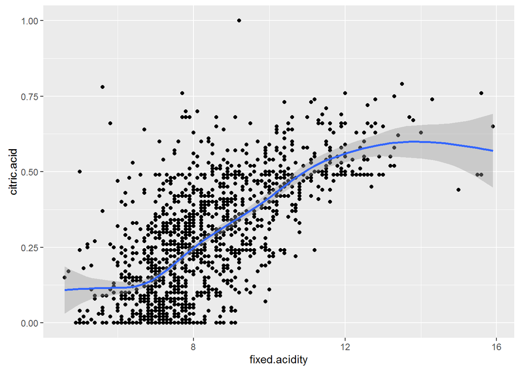

```r
qplot(fixed.acidity,citric.acid,data=wineQualityReds2,geom=c("point","smooth"))
```

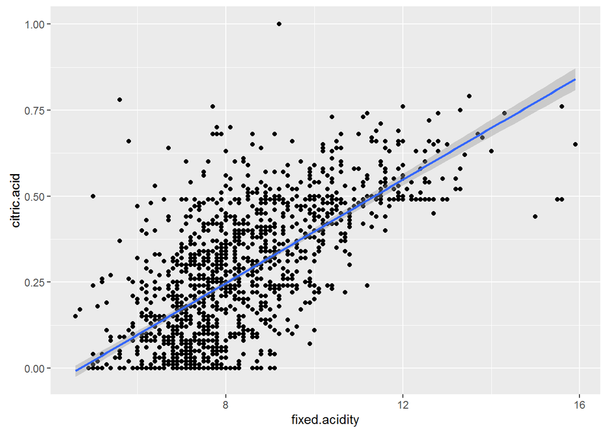

```r
g<-ggplot(wineQualityReds2,aes(fixed.acidity,citric.acid))
g+geom_point()+geom_smooth(method="lm")
```

```r
fit<-lm(citric.acid~fixed.acidity,data=wineQualityReds2)
summary(fit)
```

```
##
## Call:
## lm(formula = citric.acid ~ fixed.acidity, data = wineQualityReds2)
##
## Residuals:
##      Min       1Q   Median       3Q      Max
## -0.33302 -0.11017 -0.00938  0.09317  0.71341
##
## Coefficients:
##                Estimate Std. Error t value Pr(>|t|)
## (Intercept)   -0.354270   0.017629  -20.09   <2e-16 ***
## fixed.acidity  0.075153   0.002074   36.23   <2e-16 ***
## ---
## Signif. codes:  0 '***' 0.001 '**' 0.01 '*' 0.05 '.' 0.1 ' ' 1
##
## Residual standard error: 0.1444 on 1597 degrees of freedom
## Multiple R-squared:  0.4512, Adjusted R-squared:  0.4508
## F-statistic:  1313 on 1 and 1597 DF,  p-value: < 2.2e-16
```

It seems citric.acid has strong relationship with fixed.acidity. citric.acid grows as fixed.acidity increases.

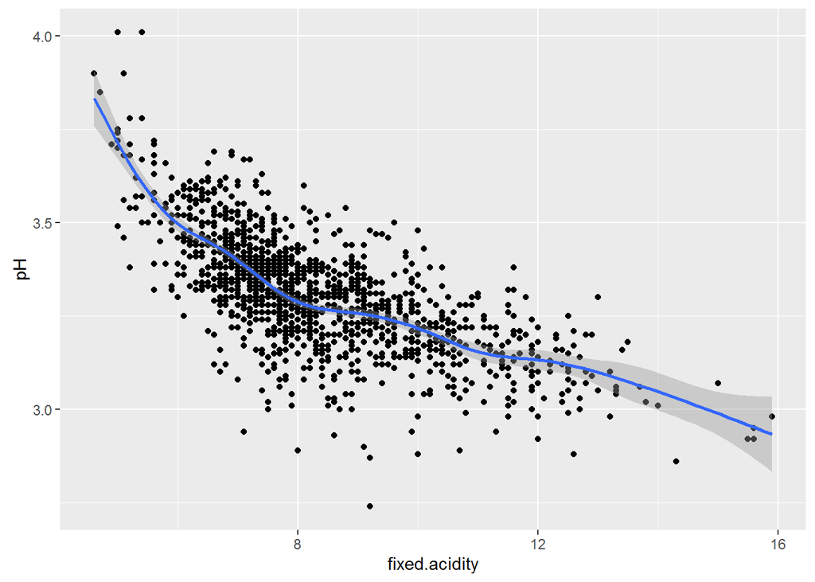

```r
qplot(fixed.acidity,pH,data=wineQualityReds2,geom=c("point","smooth"))
```

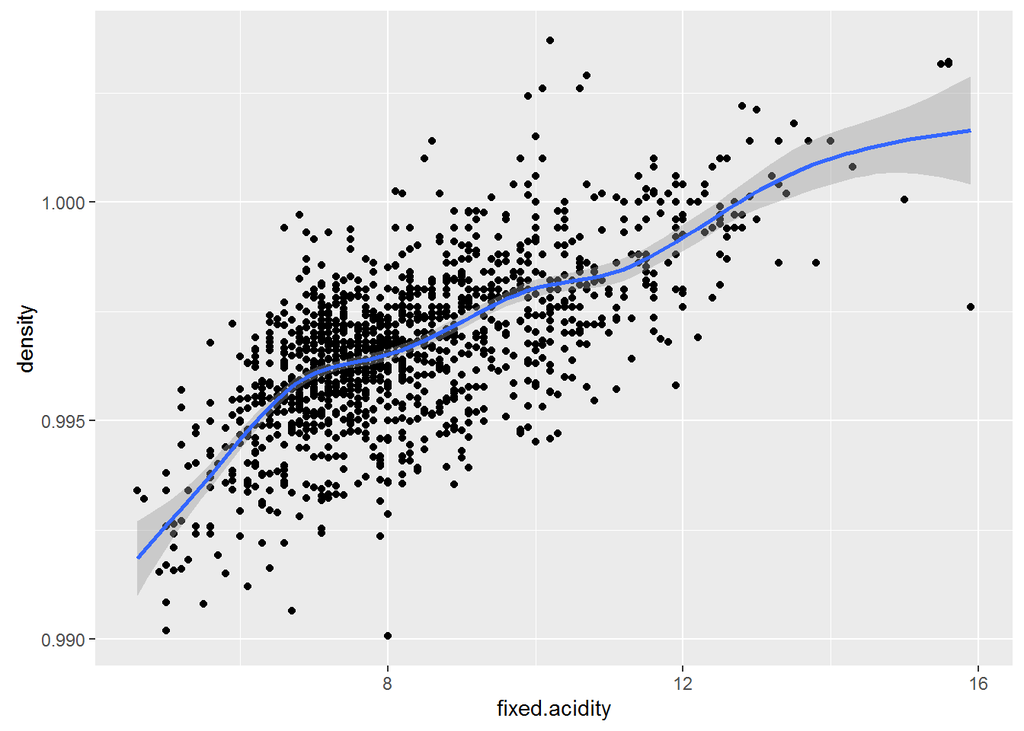

```r
qplot(fixed.acidity,density,data=wineQualityReds2,geom=c("point","smooth"))
```

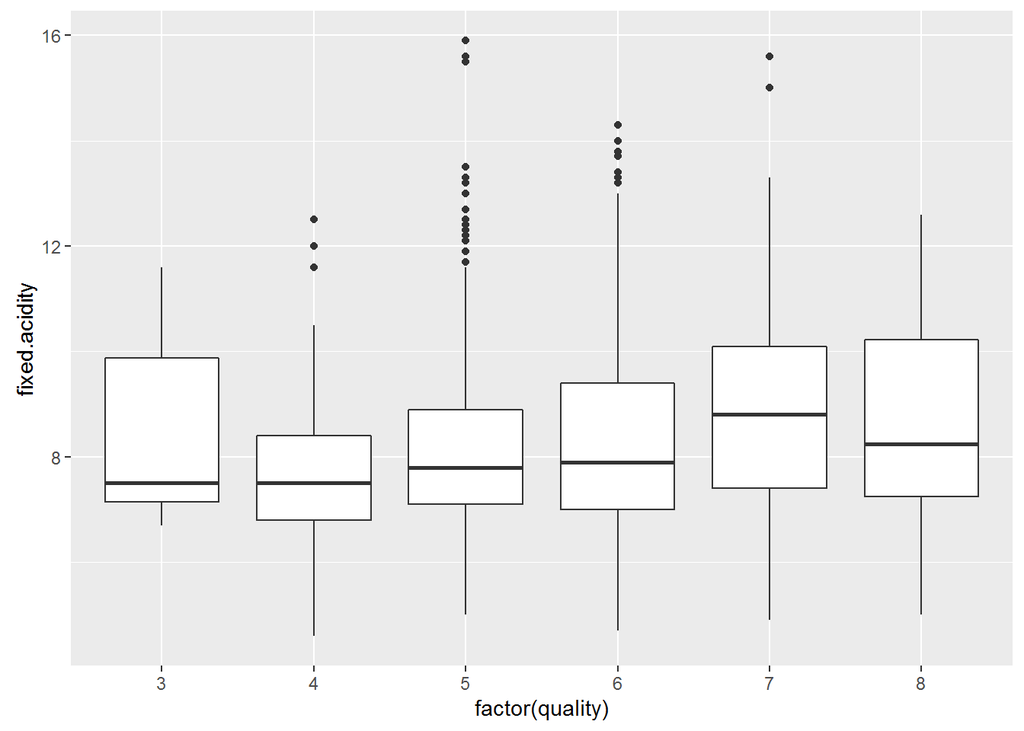

```r
qplot(factor(quality),fixed.acidity,data=wineQualityReds2,geom=("boxplot"))
```

It does show certain relationship between fixed.acidity and pH. pH decreases as fixed.acidity increases, whereas density increases as fixed.acidity increases. There are some outliers for red wines of quality 5 and 6.

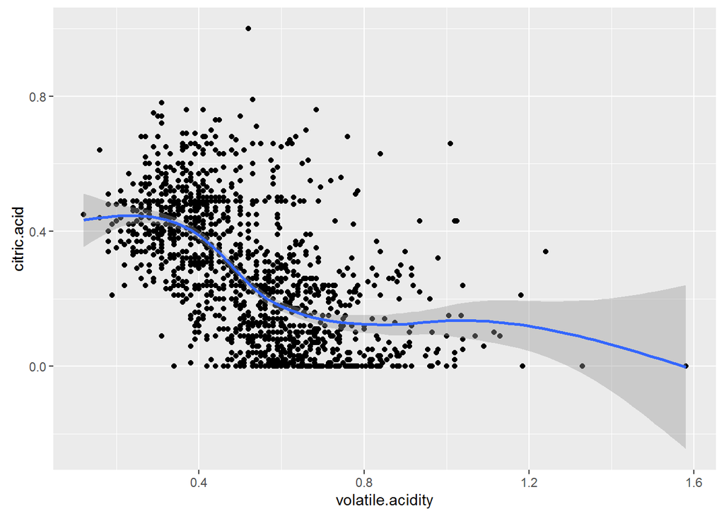

```r
qplot(volatile.acidity,citric.acid,data=wineQualityReds2,geom=c("point","smooth"))
```

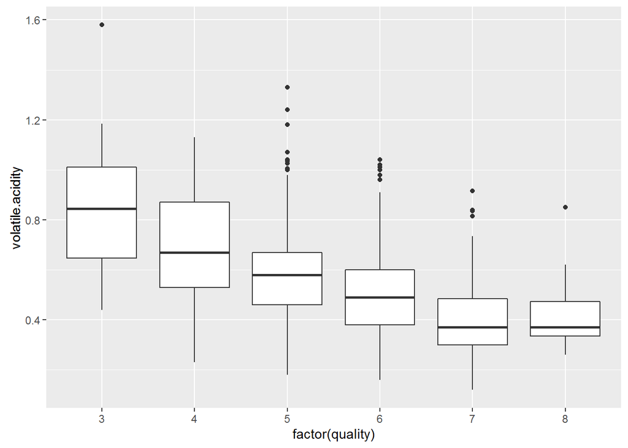

```r
qplot(factor(quality),volatile.acidity,data=wineQualityReds2,geom=("boxplot"))
```

Citric.acid decreases as volatile.acidity increases, most of citric.acid values are within 0.2 to 0.8 of volatile.acidity . There’s a tendancy that good wines have less volatile acidity averagely. Some outliers exist in red wines whose qualities are between 5 and 6.

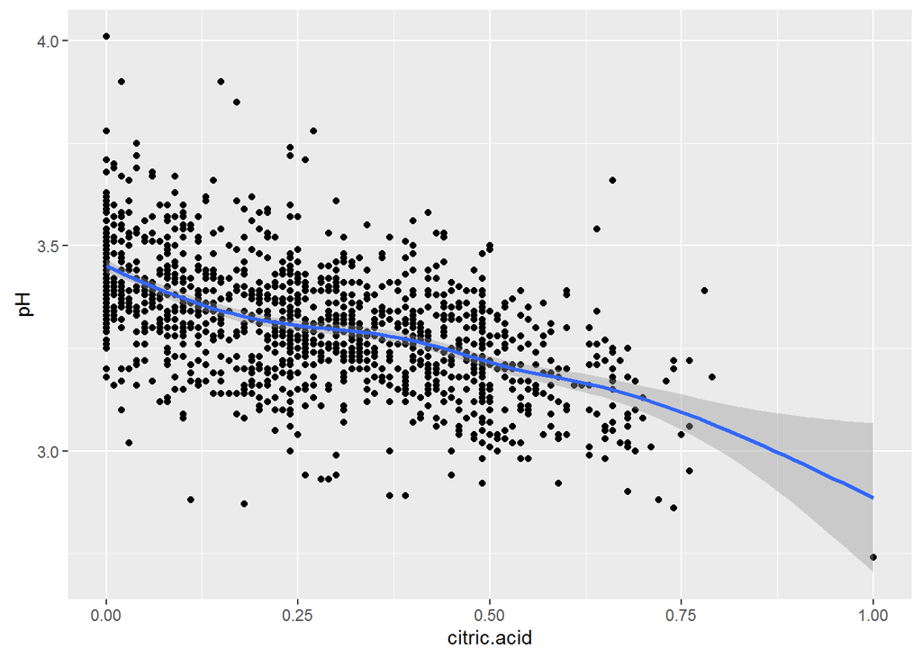

```r
qplot(citric.acid,pH,data=wineQualityReds2,geom=c("point","smooth"))
```

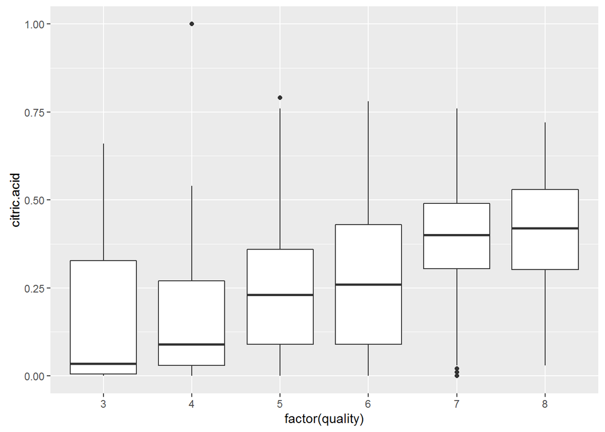

```r
qplot(factor(quality),citric.acid,data=wineQualityReds2,geom=("boxplot"))
```

Good red wines tend to have more citric acid averagely.

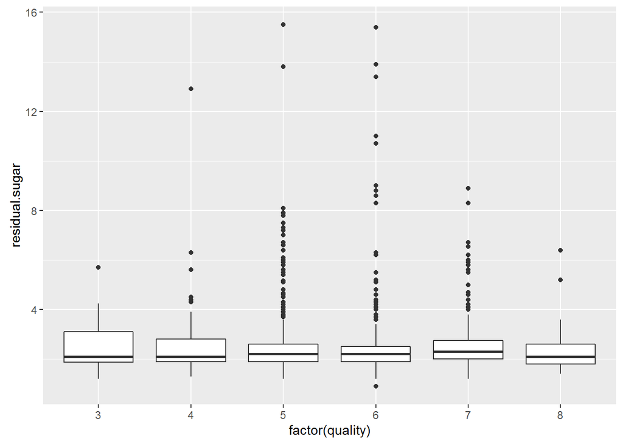

```r
qplot(factor(quality),residual.sugar,data=wineQualityReds2,geom=("boxplot"))
```

There’s no clear tendancy.

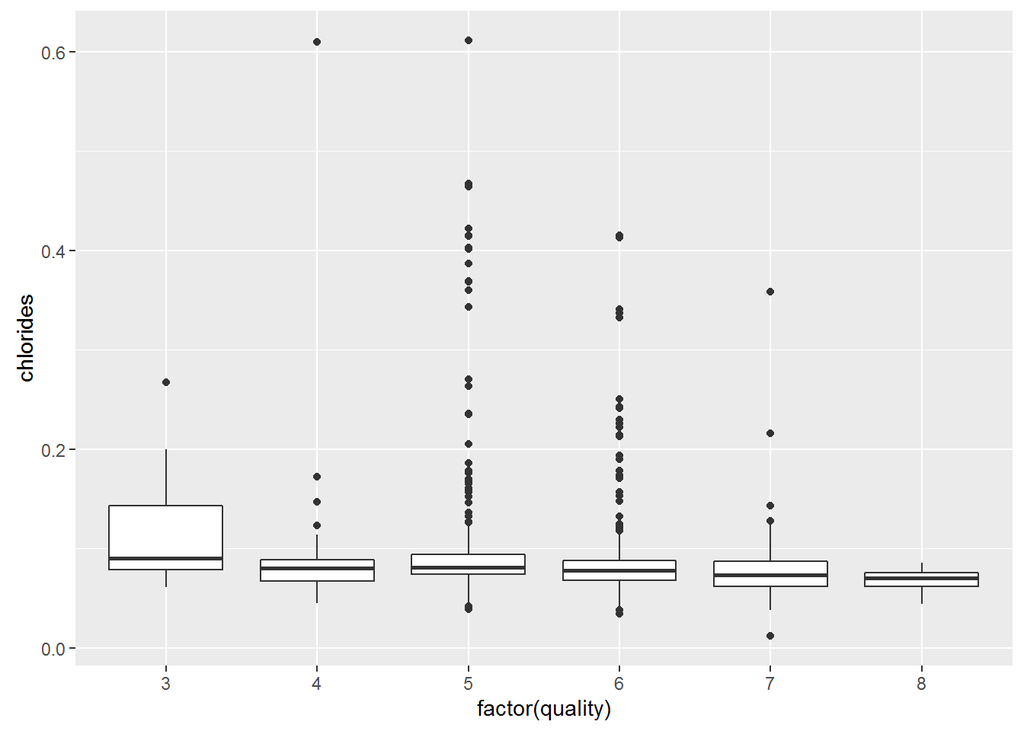

```r
qplot(factor(quality),chlorides,data=wineQualityReds2,geom=("boxplot"))
```

No clear tendancy. But there are many outliers.

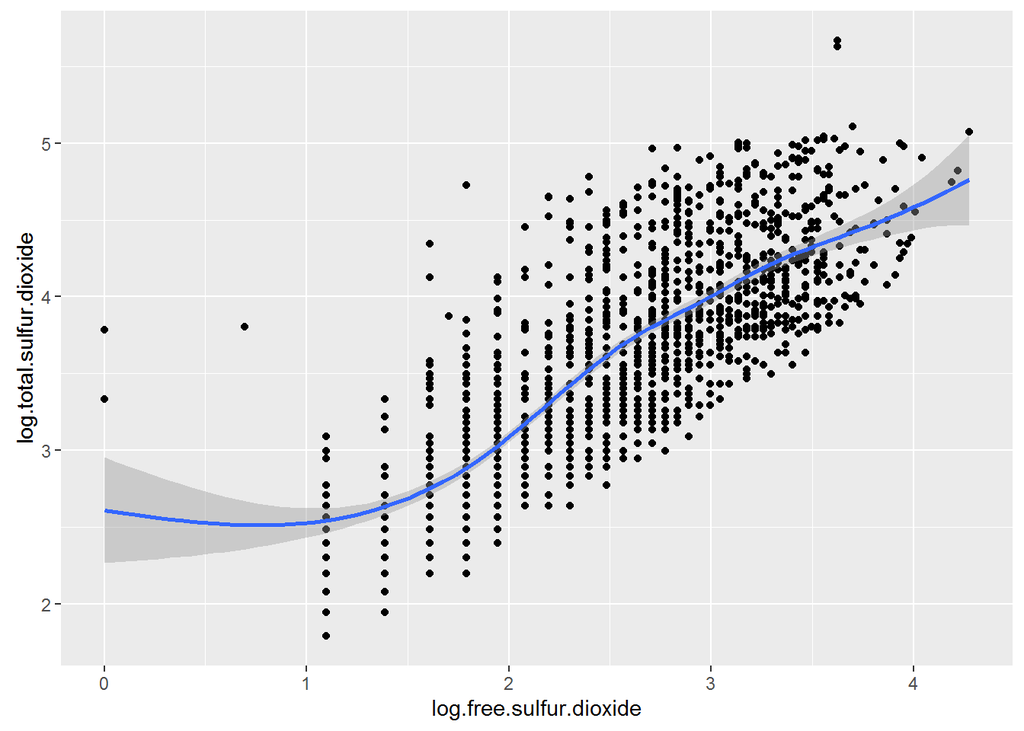

```r
qplot(log.free.sulfur.dioxide,log.total.sulfur.dioxide,data=wineQualityReds2,geom=c("point","smooth"))
```

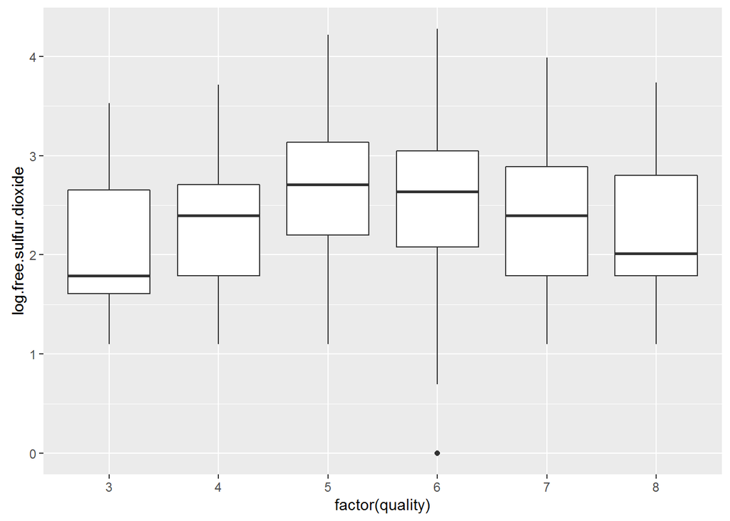

```r
qplot(factor(quality),log.free.sulfur.dioxide,data=wineQualityReds2,geom=("boxplot"))
```

The correlation is not obvious.

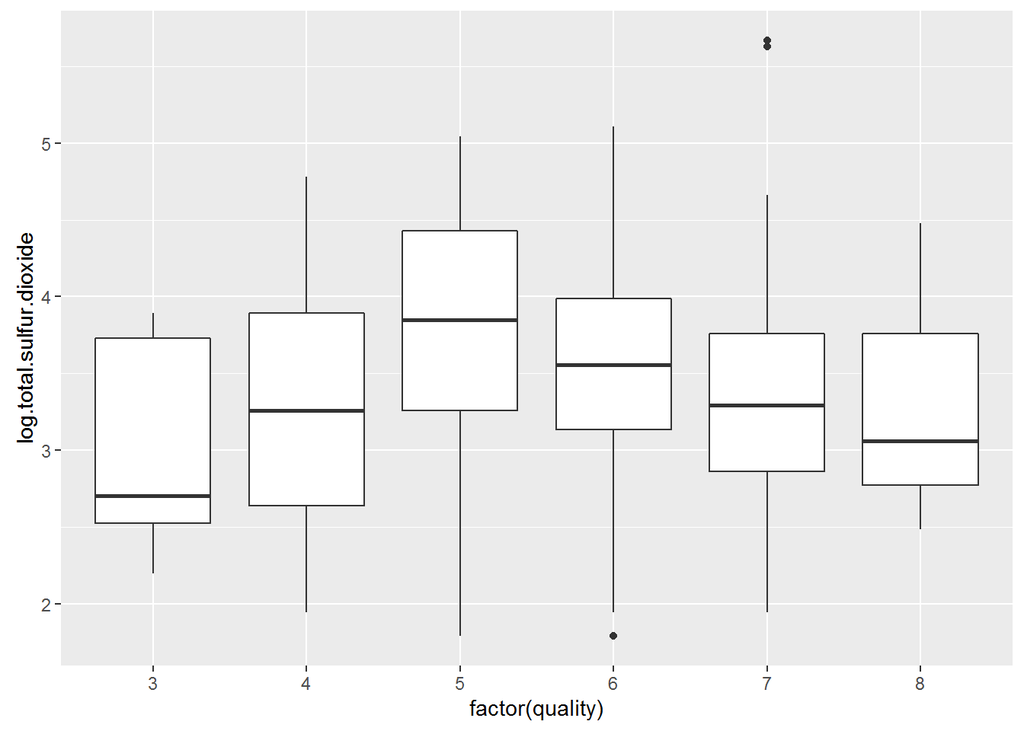

```r
qplot(factor(quality),log.total.sulfur.dioxide,data=wineQualityReds2,geom=("boxplot"))
```

No clear tendancy.

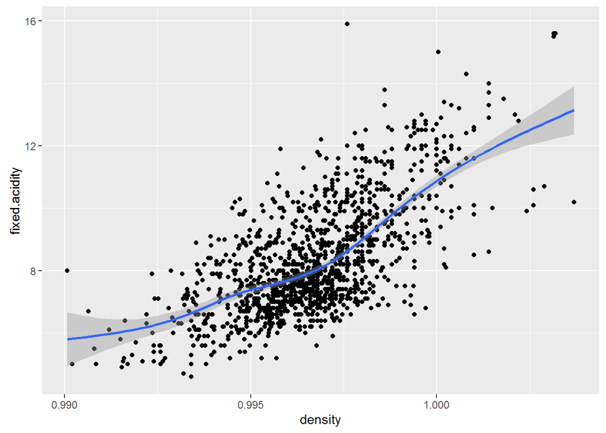

```r
qplot(density,fixed.acidity,data=wineQualityReds2,geom=c("point","smooth"))
```

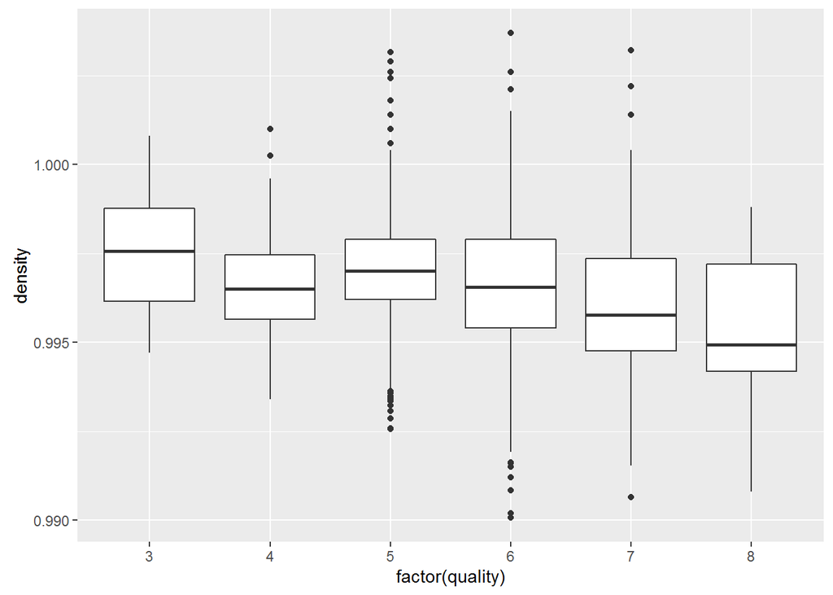

```r
qplot(factor(quality),density,data=wineQualityReds2,geom=("boxplot"))
```

No clear tendancy. There are some outliers of red wines with quality 5 and 6.

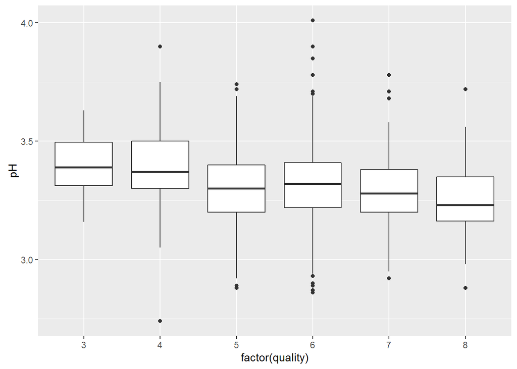

```r
qplot(factor(quality),pH,data=wineQualityReds2,geom=("boxplot"))
```

Good wines seem to have lower pH averagely. Only a few outliers here.

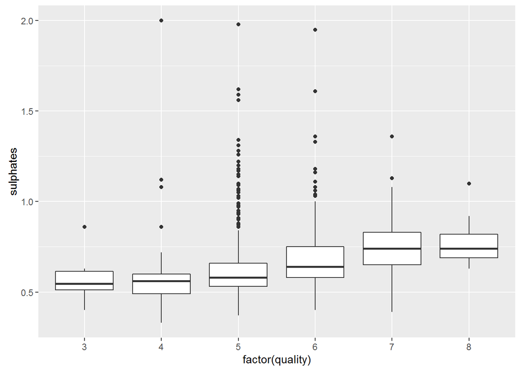

```r
qplot(factor(quality),sulphates,data=wineQualityReds2,geom=("boxplot"))
```

Good wines seem to have more sulphates averagely. There are many outliers.

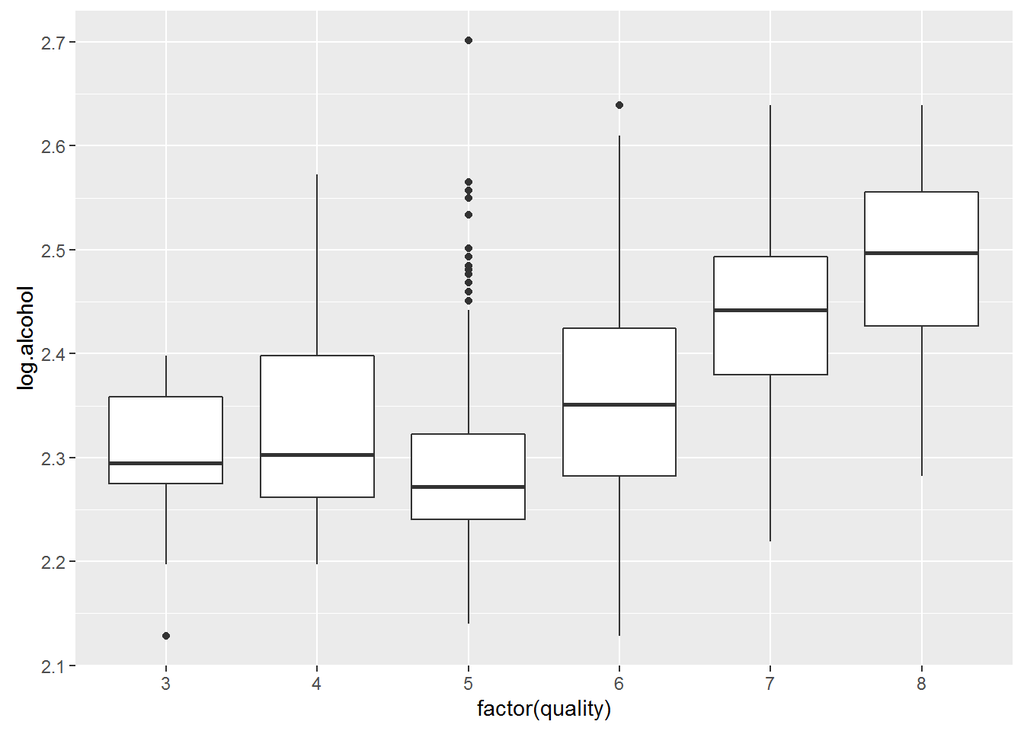

```r
qplot(factor(quality),log.alcohol,data=wineQualityReds2,geom=("boxplot"))
```

Good wines seem to have more alcohol averagely.

# Bivariate Analysis

From the boxplots above, we can see that volatile.acidity and pH have negative impact on quality, whereas sulphates and alcohol have positive impact. ### Talk about some of the relationships you observed in this part of the investigation. How did the feature(s) of interest vary with other features in the dataset? The table shows some features are correlated. For instance, citric.acid grows as fixed.acidity increases, and pH decreases as fixed.acidity increases or citric.acid increases. Besides, citric.acid decreases as volatile.acidity increases. As for the outcome “quality”, from the boxplots above, good wines tend to have less volatile acidity and lower pH averagely, whereas they tend to contain more citric acid, more sulphates and more alcohol averagely. ### Did you observe any interesting relationships between the other features (not the main feature(s) of interest)? The fixed.acidity grows as density increases, and free.sulfur.dioxide grows as total.sulfur.dioxide increases. ### What was the strongest relationship you found? According to the correlations and plots, fixed.acidity has strong relationship with citric.acid, density as well as log.PH, their correlation coefficients are above 0.6. Also, log.total.sulfur.dioxide has relationship with log.free.sulfur.dioxide and log.pH. Perhaps there are muti-correlations between several columns, we can discuss that in next step.

# Multivariate Plots Section

Correlation table can only reveal relationship between columns, there may be relationship between one and several other features, let’s use vif check them first.

```r
library(car)
fit<-lm(quality~.,data=wineQualityReds2)
vif(fit)
```

```
##            fixed.acidity         volatile.acidity              citric.acid
##                 7.715512                 1.750462                 3.082517
##           residual.sugar                chlorides                  density
##                 1.638758                 1.470762                 6.334634
##                       pH                sulphates log.total.sulfur.dioxide
##                 3.273020                 1.442760                76.013238
##    log.bf.sulfur.dioxide  log.free.sulfur.dioxide              log.alcohol
##                42.887294                12.234791                 2.972851
```

It is clear from the linear regression that fixed.acidity, log.total.sulfur.dioxide, log.bf.sulfur.dioxide, log.free.sulfur.dioxide and density are quite dependant on other features. We use linear regression to check the relationship between variables.

```r
fit<-lm(fixed.acidity~.-quality,data=wineQualityReds2)
summary(fit)
```

```
##
## Call:
## lm(formula = fixed.acidity ~ . - quality, data = wineQualityReds2)
##
## Residuals:
##     Min      1Q  Median      3Q     Max
## -2.8244 -0.3681 -0.0214  0.3651  4.0081
##
## Coefficients:
##                            Estimate Std. Error t value Pr(>|t|)
## (Intercept)              -648.73025   12.99346 -49.927  < 2e-16 ***
## volatile.acidity            0.16732    0.11618   1.440    0.150
## citric.acid                 1.85786    0.13392  13.872  < 2e-16 ***
## residual.sugar             -0.25286    0.01280 -19.757  < 2e-16 ***
## chlorides                  -3.56997    0.39541  -9.029  < 2e-16 ***
## density                   664.07897   12.74345  52.111  < 2e-16 ***
## pH                         -5.23034    0.12946 -40.403  < 2e-16 ***
## sulphates                  -0.66629    0.11023  -6.044 1.87e-09 ***
## log.total.sulfur.dioxide   -0.09469    0.19446  -0.487    0.626
## log.bf.sulfur.dioxide      -0.16053    0.12404  -1.294    0.196
## log.free.sulfur.dioxide     0.09630    0.08027   1.200    0.230
## log.alcohol                 5.91744    0.23061  25.660  < 2e-16 ***
## ---
## Signif. codes:  0 '***' 0.001 '**' 0.01 '*' 0.05 '.' 0.1 ' ' 1
##
## Residual standard error: 0.629 on 1587 degrees of freedom
## Multiple R-squared:  0.8704, Adjusted R-squared:  0.8695
## F-statistic: 968.9 on 11 and 1587 DF,  p-value: < 2.2e-16
```

It seems fixed.acidity has strong linear relationship with citric.acid, residual.sugar, chlorides, density, pH, sulphates and log.alcohol.

```r
fit<-lm(log.total.sulfur.dioxide~.-quality,data=wineQualityReds2)
summary(fit)
```

```
##
## Call:
## lm(formula = log.total.sulfur.dioxide ~ . - quality, data = wineQualityReds2)
##
## Residuals:
##      Min       1Q   Median       3Q      Max
## -0.10948 -0.04857 -0.02462  0.01984  0.73954
##
## Coefficients:
##                           Estimate Std. Error t value Pr(>|t|)
## (Intercept)              5.4391747  2.6855840   2.025 0.043001 *
## fixed.acidity           -0.0015776  0.0032399  -0.487 0.626373
## volatile.acidity         0.0251847  0.0149931   1.680 0.093202 .
## citric.acid             -0.0429885  0.0182727  -2.353 0.018764 *
## residual.sugar           0.0009931  0.0018438   0.539 0.590241
## chlorides               -0.0618340  0.0523091  -1.182 0.237347
## density                 -4.6998323  2.7058126  -1.737 0.082592 .
## pH                      -0.0313498  0.0237862  -1.318 0.187700
## sulphates                0.0496970  0.0143374   3.466 0.000542 ***
## log.bf.sulfur.dioxide    0.6248652  0.0032526 192.114  < 2e-16 ***
## log.free.sulfur.dioxide  0.3858139  0.0036965 104.373  < 2e-16 ***
## log.alcohol              0.0101627  0.0354062   0.287 0.774127
## ---
## Signif. codes:  0 '***' 0.001 '**' 0.01 '*' 0.05 '.' 0.1 ' ' 1
##
## Residual standard error: 0.08119 on 1587 degrees of freedom
## Multiple R-squared:  0.9868, Adjusted R-squared:  0.9868
## F-statistic: 1.082e+04 on 11 and 1587 DF,  p-value: < 2.2e-16
```

It seems log.total.sulfur.dioxide has strong linear relationship with sulphates, log.bf.sulfur.dioxide and log.free.sulfur.dioxide.

```r
fit<-lm(log.bf.sulfur.dioxide~.-quality,data=wineQualityReds2)
summary(fit)
```

```
##
## Call:
## lm(formula = log.bf.sulfur.dioxide ~ . - quality, data = wineQualityReds2)
##
## Residuals:
##      Min       1Q   Median       3Q      Max
## -1.04549 -0.02472  0.03431  0.07489  0.22527
##
## Coefficients:
##                            Estimate Std. Error t value Pr(>|t|)
## (Intercept)              -13.187780   4.200748  -3.139  0.00172 **
## fixed.acidity             -0.006568   0.005075  -1.294  0.19578
## volatile.acidity          -0.009270   0.023514  -0.394  0.69345
## citric.acid                0.119763   0.028525   4.198 2.84e-05 ***
## residual.sugar            -0.001686   0.002889  -0.584  0.55951
## chlorides                  0.034293   0.082000   0.418  0.67586
## density                   12.421848   4.232593   2.935  0.00339 **
## pH                         0.001879   0.037294   0.050  0.95982
## sulphates                 -0.072538   0.022478  -3.227  0.00128 **
## log.total.sulfur.dioxide   1.534369   0.007987 192.114  < 2e-16 ***
## log.free.sulfur.dioxide   -0.566105   0.007870 -71.936  < 2e-16 ***
## log.alcohol               -0.053805   0.055467  -0.970  0.33218
## ---
## Signif. codes:  0 '***' 0.001 '**' 0.01 '*' 0.05 '.' 0.1 ' ' 1
##
## Residual standard error: 0.1272 on 1587 degrees of freedom
## Multiple R-squared:  0.9767, Adjusted R-squared:  0.9765
## F-statistic:  6043 on 11 and 1587 DF,  p-value: < 2.2e-16
```

```r
fit<-lm(log.free.sulfur.dioxide~.-quality,data=wineQualityReds2)
summary(fit)
```

```
##
## Call:
## lm(formula = log.free.sulfur.dioxide ~ . - quality, data = wineQualityReds2)
##
## Residuals:
##      Min       1Q   Median       3Q      Max
## -2.04439 -0.05789  0.05074  0.11822  0.27041
##
## Coefficients:
##                           Estimate Std. Error t value Pr(>|t|)
## (Intercept)              -3.213380   6.511131  -0.494   0.6217
## fixed.acidity             0.009408   0.007842   1.200   0.2304
## volatile.acidity         -0.105054   0.036243  -2.899   0.0038 **
## citric.acid               0.029953   0.044319   0.676   0.4992
## residual.sugar            0.004513   0.004464   1.011   0.3122
## chlorides                 0.137097   0.126677   1.082   0.2793
## density                   1.451118   6.558340   0.221   0.8249
## pH                        0.143963   0.057517   2.503   0.0124 *
## sulphates                -0.072155   0.034803  -2.073   0.0383 *
## log.total.sulfur.dioxide  2.262345   0.021676 104.373   <2e-16 ***
## log.bf.sulfur.dioxide    -1.351868   0.018793 -71.936   <2e-16 ***
## log.alcohol              -0.064522   0.085724  -0.753   0.4518
## ---
## Signif. codes:  0 '***' 0.001 '**' 0.01 '*' 0.05 '.' 0.1 ' ' 1
##
## Residual standard error: 0.1966 on 1587 degrees of freedom
## Multiple R-squared:  0.9183, Adjusted R-squared:  0.9177
## F-statistic:  1621 on 11 and 1587 DF,  p-value: < 2.2e-16
```

Now let’s have a look at density.

```r
fit<-lm(density~.-quality,data=wineQualityReds2)
summary(fit)
```

```
##
## Call:
## lm(formula = density ~ . - quality, data = wineQualityReds2)
##
## Residuals:
##        Min         1Q     Median         3Q        Max
## -0.0033882 -0.0004215 -0.0000153  0.0004237  0.0030181
##
## Coefficients:
##                            Estimate Std. Error  t value Pr(>|t|)
## (Intercept)               9.923e-01  8.416e-04 1179.051  < 2e-16 ***
## fixed.acidity             9.504e-04  1.824e-05   52.111  < 2e-16 ***
## volatile.acidity          6.944e-04  1.380e-04    5.032  5.4e-07 ***
## citric.acid              -8.953e-05  1.696e-04   -0.528 0.597741
## residual.sugar            4.019e-04  1.380e-05   29.130  < 2e-16 ***
## chlorides                 1.775e-03  4.830e-04    3.675 0.000245 ***
## pH                        5.048e-03  1.805e-04   27.958  < 2e-16 ***
## sulphates                 1.300e-03  1.293e-04   10.055  < 2e-16 ***
## log.total.sulfur.dioxide -4.037e-04  2.324e-04   -1.737 0.082592 .
## log.bf.sulfur.dioxide     4.346e-04  1.481e-04    2.935 0.003386 **
## log.free.sulfur.dioxide   2.126e-05  9.608e-05    0.221 0.824916
## log.alcohol              -9.613e-03  2.224e-04  -43.219  < 2e-16 ***
## ---
## Signif. codes:  0 '***' 0.001 '**' 0.01 '*' 0.05 '.' 0.1 ' ' 1
##
## Residual standard error: 0.0007525 on 1587 degrees of freedom
## Multiple R-squared:  0.8421, Adjusted R-squared:  0.841
## F-statistic: 769.6 on 11 and 1587 DF,  p-value: < 2.2e-16
```

Density is strongly correlated with fixed.acidity, volatile.acidity, residual.sugar and etc. In our next steps, we can disregard fixed.acidity, total.sulfur.dioxide, density. There are no categorical features, so we can cut some into intervals to do danalysis.

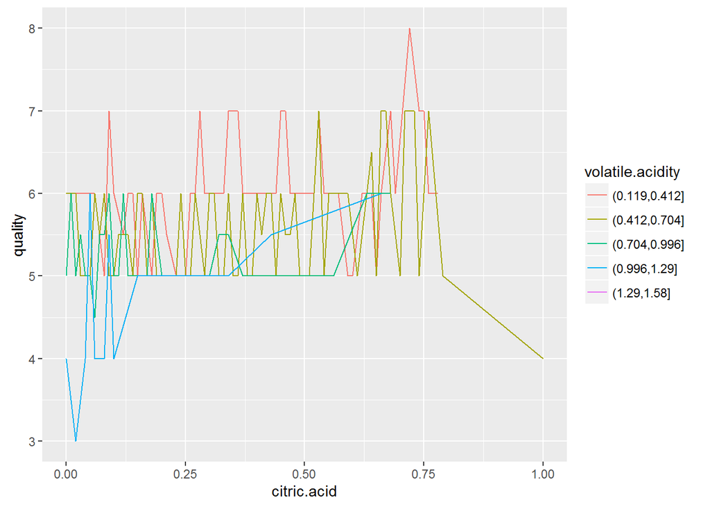

```r
wineQualityReds3<-wineQualityReds2
wineQualityReds3$volatile.acidity<-cut(wineQualityReds3$volatile.acidity,5)
g<-ggplot(wineQualityReds3,aes(citric.acid,quality))
g+geom_line(aes(colour=volatile.acidity),stat='summary',fun.y=median)
```

It seems that when volatile.acidity has a big value and citric.acid has a small value, the red wine has a lower quality.

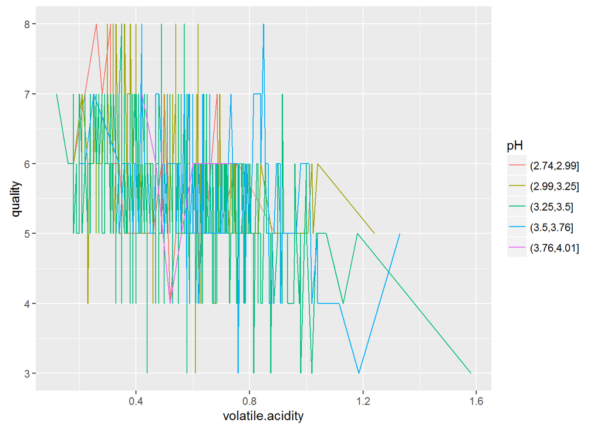

```r
wineQualityReds3<-wineQualityReds2
wineQualityReds3$pH<-cut(wineQualityReds3$pH,5)
g<-ggplot(wineQualityReds3,aes(volatile.acidity,quality))
g+geom_line(aes(colour=pH))
```

It seems that when volatile.acidity has a big value and pH has a big value, the red wine has a lower quality. Let’s use linear regression to explore the multivariate relationships. The scales of features are not hugely different, so we do not normalize them.

```r
fit1<-lm(quality~.-fixed.acidity-density-log.total.sulfur.dioxide-density,data=wineQualityReds2)
summary(fit1)
```

```
##
## Call:
## lm(formula = quality ~ . - fixed.acidity - density - log.total.sulfur.dioxide -
##     density, data = wineQualityReds2)
##
## Residuals:
##      Min       1Q   Median       3Q      Max
## -2.69632 -0.35706 -0.05722  0.45824  2.06699
##
## Coefficients:
##                          Estimate Std. Error t value Pr(>|t|)
## (Intercept)              0.476439   0.566947   0.840   0.4008
## volatile.acidity        -1.101919   0.115928  -9.505  < 2e-16 ***
## citric.acid             -0.130797   0.123744  -1.057   0.2907
## residual.sugar           0.007312   0.011881   0.615   0.5383
## chlorides               -1.853139   0.403828  -4.589 4.81e-06 ***
## pH                      -0.520957   0.133451  -3.904 9.87e-05 ***
## sulphates                0.890081   0.110926   8.024 1.97e-15 ***
## log.bf.sulfur.dioxide   -0.109294   0.025351  -4.311 1.72e-05 ***
## log.free.sulfur.dioxide  0.050540   0.029376   1.720   0.0855 .
## log.alcohol              3.107028   0.190370  16.321  < 2e-16 ***
## ---
## Signif. codes:  0 '***' 0.001 '**' 0.01 '*' 0.05 '.' 0.1 ' ' 1
##
## Residual standard error: 0.649 on 1589 degrees of freedom
## Multiple R-squared:  0.3578, Adjusted R-squared:  0.3542
## F-statistic: 98.39 on 9 and 1589 DF,  p-value: < 2.2e-16
```

From the p-values, we can see that residual.sugar, citric.acid are not so important in terms of quality.

```r
fit2<-lm(quality~.-fixed.acidity-density-log.total.sulfur.dioxide-density-residual.sugar-citric.acid,data=wineQualityReds2)
summary(fit2)
```

```
##
## Call:
## lm(formula = quality ~ . - fixed.acidity - density - log.total.sulfur.dioxide -
##     density - residual.sugar - citric.acid, data = wineQualityReds2)
##
## Residuals:
##      Min       1Q   Median       3Q      Max
## -2.72464 -0.36351 -0.05637  0.46530  2.06301
##
## Coefficients:
##                         Estimate Std. Error t value Pr(>|t|)
## (Intercept)              0.30474    0.54257   0.562   0.5744
## volatile.acidity        -1.03989    0.10046 -10.351  < 2e-16 ***
## chlorides               -1.90600    0.39853  -4.783 1.89e-06 ***
## pH                      -0.46075    0.11753  -3.920 9.22e-05 ***
## sulphates                0.87812    0.11042   7.953 3.43e-15 ***
## log.bf.sulfur.dioxide   -0.11251    0.02477  -4.543 5.98e-06 ***
## log.free.sulfur.dioxide  0.05585    0.02900   1.926   0.0543 .
## log.alcohol              3.07780    0.18518  16.621  < 2e-16 ***
## ---
## Signif. codes:  0 '***' 0.001 '**' 0.01 '*' 0.05 '.' 0.1 ' ' 1
##
## Residual standard error: 0.6488 on 1591 degrees of freedom
## Multiple R-squared:  0.3573, Adjusted R-squared:  0.3545
## F-statistic: 126.4 on 7 and 1591 DF,  p-value: < 2.2e-16
```

F-statistic is quite large, so the model works. But the Adjusted R-squared is not large, perhaps some interactions between features or even polynomial exist.

```r
fit3<-lm(quality~volatile.acidity+sulphates+pH+chlorides+log.alcohol+log.bf.sulfur.dioxide+log.free.sulfur.dioxide+I(sulphates*pH),data=wineQualityReds2)
summary(fit3)
```

```
##
## Call:
## lm(formula = quality ~ volatile.acidity + sulphates + pH + chlorides +
##     log.alcohol + log.bf.sulfur.dioxide + log.free.sulfur.dioxide +
##     I(sulphates * pH), data = wineQualityReds2)
##
## Residuals:
##      Min       1Q   Median       3Q      Max
## -2.87380 -0.36934 -0.04765  0.45634  2.12862
##
## Coefficients:
##                         Estimate Std. Error t value Pr(>|t|)
## (Intercept)              6.64356    1.22537   5.422 6.81e-08 ***
## volatile.acidity        -0.93244    0.10120  -9.214  < 2e-16 ***
## sulphates               -8.56971    1.64517  -5.209 2.15e-07 ***
## pH                      -2.46713    0.36751  -6.713 2.64e-11 ***
## chlorides               -1.29419    0.40863  -3.167  0.00157 **
## log.alcohol              3.06724    0.18335  16.729  < 2e-16 ***
## log.bf.sulfur.dioxide   -0.11181    0.02452  -4.559 5.52e-06 ***
## log.free.sulfur.dioxide  0.05332    0.02872   1.857  0.06352 .
## I(sulphates * pH)        2.96281    0.51478   5.755 1.03e-08 ***
## ---
## Signif. codes:  0 '***' 0.001 '**' 0.01 '*' 0.05 '.' 0.1 ' ' 1
##
## Residual standard error: 0.6424 on 1590 degrees of freedom
## Multiple R-squared:  0.3704, Adjusted R-squared:  0.3672
## F-statistic: 116.9 on 8 and 1590 DF,  p-value: < 2.2e-16
```

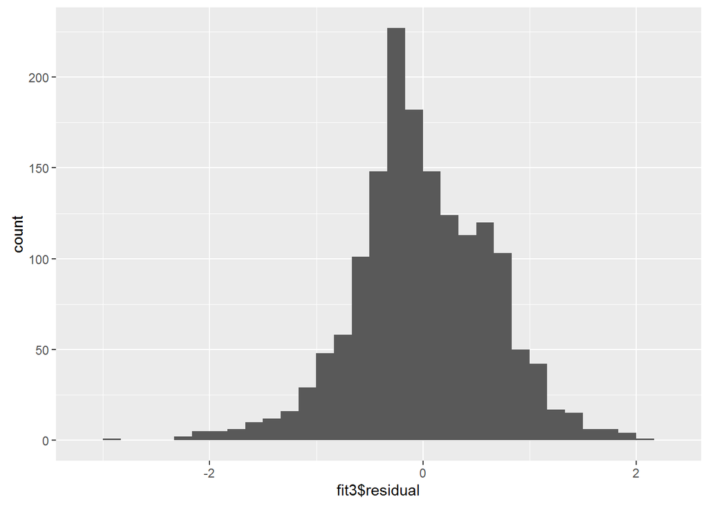

```r
qplot(fit3$residual)
```

```r
summary(fit3$residual)
```

```
##     Min.  1st Qu.   Median     Mean  3rd Qu.     Max.
## -2.87400 -0.36930 -0.04765  0.00000  0.45630  2.12900
```

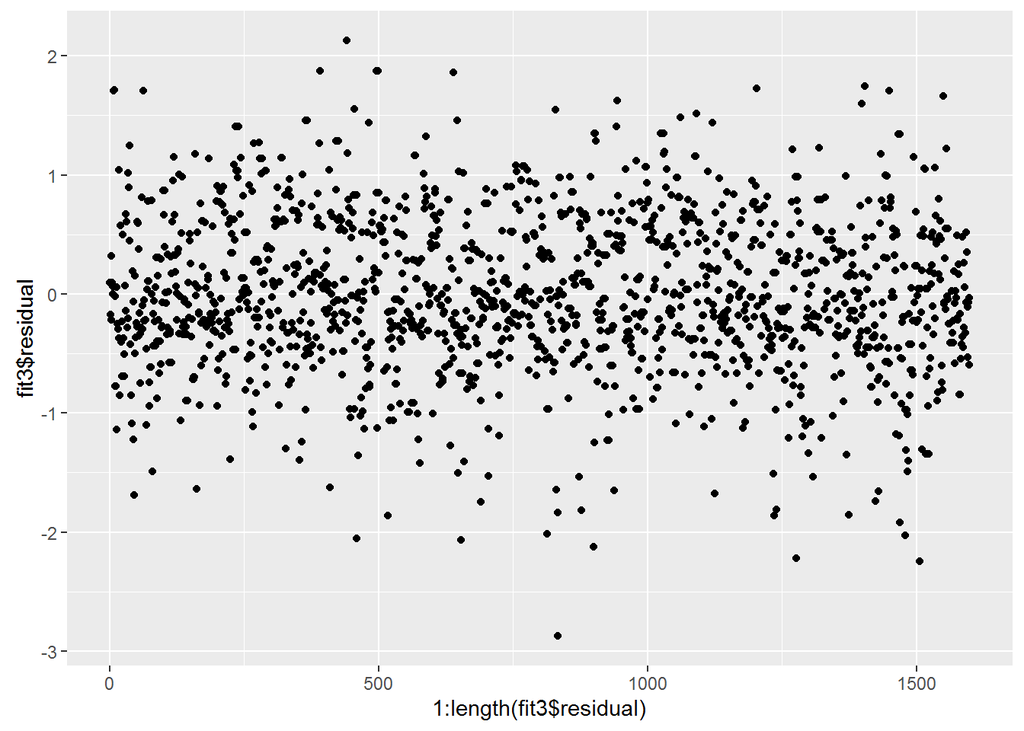

```r
qplot(1:length(fit3$residual),fit3$residual)
```

It seems the produce of sulphates and pH are also correlated to quality. The residuals are almost normally distributed, so the linear model works.

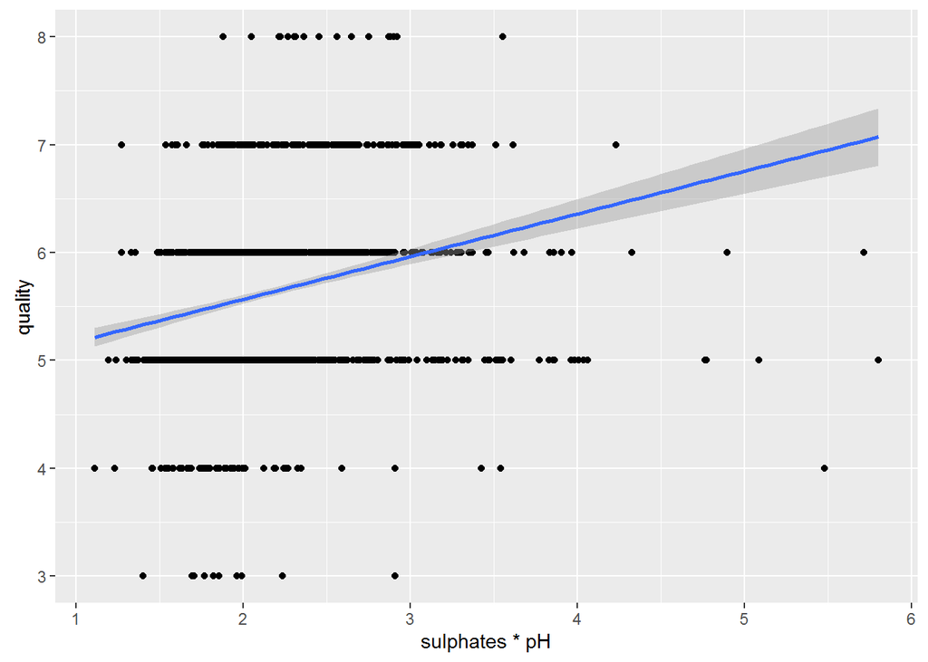

```r
g<-ggplot(wineQualityReds2,aes(sulphates*pH,quality))
g+geom_point()+geom_smooth(method="lm")
```

# Multivariate Analysis

### Talk about some of the relationships you observed in this part of the investigation. Were there features that strengthened each other in terms of looking at your feature(s) of interest?

From the figures and regression discussed above, volatile.acidity, sulphates, pH, chlorides,log.alcohol, log.bf.sulfur.dioxide and log.free.sulfur.dioxide, they strengthened each other in deciding the quality of red wine. ### Were there any interesting or surprising interactions between features? Interaction, product of sulphates and pH(sulphates*pH), they appeared to be correlated to quality. ### OPTIONAL: Did you create any models with your dataset? Discuss the strengths and limitations of your model. I created a linear model to explore the relationship between quality and other features. The strengths are that it is easy to understand the model, the quality has a linear relationship with other features, the impact of each feature can be calculated quickly. Besides, linear model can work on new dataset well. The limitations is that linear model lacks flexibility, perhaps the real relationship is not so simple, the RSE can be more ideal if we use a more proper model such as polynomial model. ——

# Final Plots and Summary

### Plot One

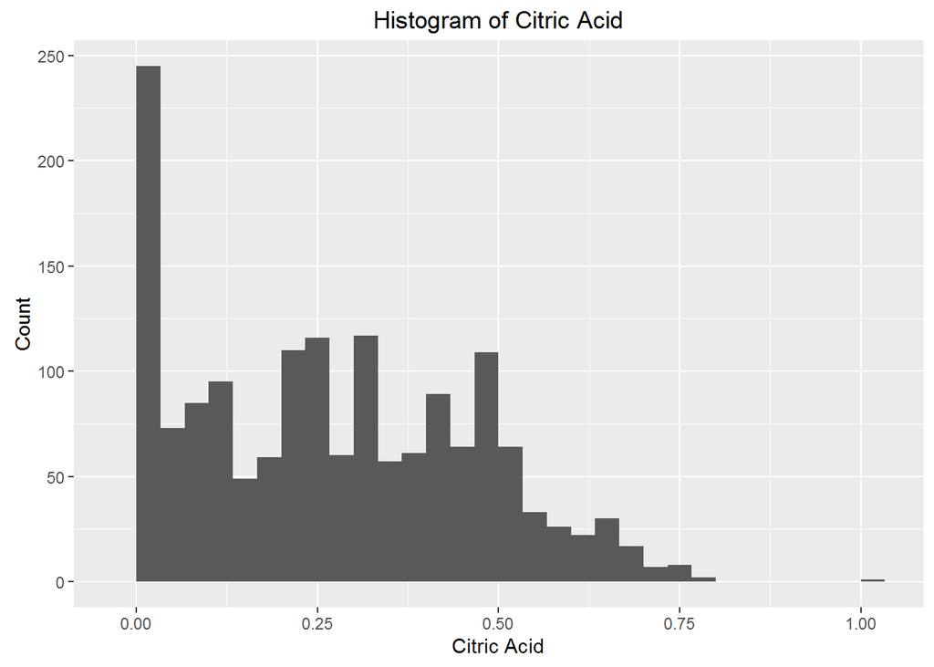

### Description One

The values of Citric Acid are right skewed.

### Plot Two

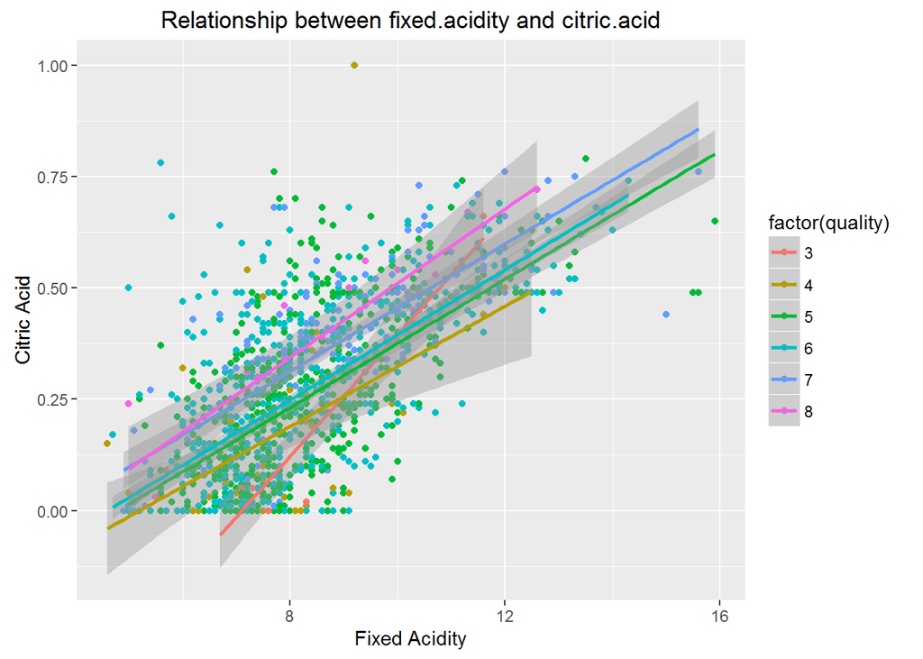

### Description Two

Some features are quite correlated with others, i.e., fixed.acidity has certain linear relationship with citric.acid.

### Plot Three

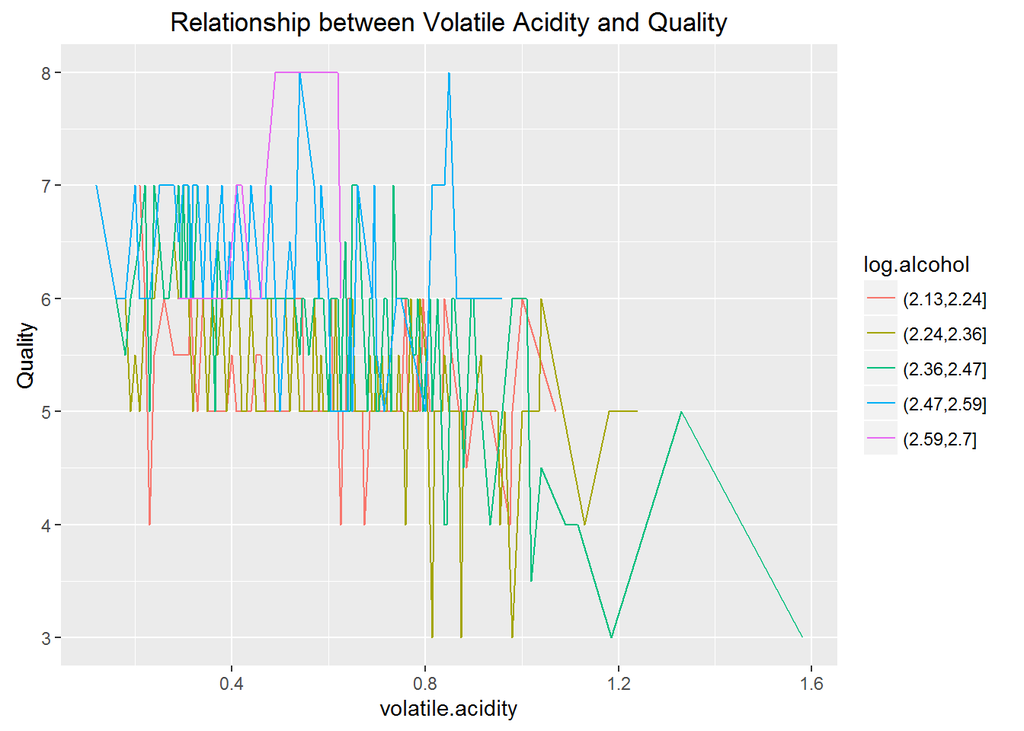

# Reflection

The wineQualityReds dataset has 1599 red wines whose qualities range from 3 to 8.I started by analyzing each features in the dataset through histograms and summary, and then I explored the relationship between features and outcome. Eventually, I explored the quality of red wine across many variables and created a linear model to predict qualities. I found features volatile.acidity and pH have negative impact on quality, whereas the interaction (sulphates*pH) and alcohol have positive impact both from boxplots and linear model. In addition, features such as fixed.acidity, total.sulfur.dioxide and density are quite dependent on other features, so I did not consider them in later discussion. For the linear model, I tried to find the relationship between quality and significant features according to p-values and adjusted R-squared, finally I only kept volatile.acidity, chlorides, pH, sulphates bf.sulfur.dioxide(newly created variable), free.sulfur.dioxide and alcohol as siginificant features. Some limitations of this model were, lack of fexibility to explore nonlinear relationship. Considering that most of red wines have qualities ranging from 5 to 7, there are just a few samples for bad and top wines, perhaps the model will do better if the dataset are balanced.